[figure not shown]

**By:JC**

# **数据挖掘第一章-导论**

[figure not shown]

# 前情提要：轻代码、重思想、重算法

## 一：为什么我们需要数据挖掘

数据挖掘是一种从大量数据中自动发现有用信息的过程。  
随着数据的增长和复杂性的增加，数据挖掘变得越来越重要。  
现实生活的数据中隐含着许多有价值的信息，但是这些信息需要我们去以各种手段去挖掘并且呈现出来。  
在向别人呈现工作的时候你不可能给人excel数据让人去看一列列的数字。

1. 揭示潜在模式

数据挖掘可以帮助我们发现数据中隐藏的潜在模式。通过分析大量数据，我们可以识别有趣的、非显然的关系，从而揭示数据中的潜在模式。  
这些模式可以用于优化业务决策、开发新产品和改进现有产品等方面。  
经典案例：沃尔玛超市管理人员分析其销售数据时发现“啤酒”与“尿布”这两件商品会出现在美国消费者的同一个购物篮中。  
2. 预测未来趋势  
通过数据挖掘，我们可以利用历史数据来预测未来趋势。这对于业务决策、市场研究和资源分配等方面非常有用。  
经典案例：机器学习中的股价预测、银行贷款违约预测...  
3. 发现异常  
数据挖掘可以帮助我们发现数据中的异常值和离群值。这对于识别欺诈、检测错误和发现异常行为等方面非常有用。  
4. 提高效率：  
通过数据挖掘技术可以将数据处理过程自动化，并且可以灵活的选择可视化工具，快速发现数据集中的规律。  
或者通过现有的机器学习技术来快速发现变量之间的相互关系，减少开发时间。  
5. 优化资源分配  
通过数据挖掘技术，可以分析历史数据、实时数据和未来趋势，来优化资源的分配。  
客户分群：将客户按照其需求、行为和购买历史等因素进行分类，以便将资源和服务优先分配给高价值的客户。  
预测需求：使用历史数据和趋势来预测未来的需求，以便优化生产和库存规划。  
供应链优化：分析供应链的历史数据和实时数据，以便找到瓶颈、优化流程和减少浪费。  
6. 探索新的机会  
数据挖掘可以帮助我们发现新的商业机会。通过分析市场趋势、消费者行为和竞争情况等，  
我们可以了解市场上的未满足需求和新的商业机会，从而为公司的未来发展提供支持。

## 二：如何进行数据挖掘/数据挖掘的步骤

1. 业务理解或问题定义

确定研究目标和需要解决的问题。这一步需要明确问题的定义、目标和假设等。  
2. 数据采集  
收集与问题相关的数据。可以使用现有数据源，例如企业内部数据库、公共数据库、社交媒体等，也可以通过在线调查、实验室测试等方法采集数据。  
3. 数据处理  
数据预处理、特征工程、数据集划分等等。后面章节细讲  
4. 建立模型  
选择合适的模型，建立数据挖掘模型。常用的模型包括决策树、神经网络、支持向量机、朴素贝叶斯等。  
使用训练集训练模型。在训练过程中，需要根据训练集调整模型参数，以提高模型的准确性和泛化能力。  
使用测试集评估模型的准确性和泛化能力。常用的评估指标包括准确率、召回率、精确度、F1值等。  
5. 模型优化  
在模型评估的基础上，优化模型以提高模型的准确性和泛化能力。常见的优化方法包括参数调整、特征选择和模型集成等。  
提高模型在实际场景的应用能力。  
6. 模型部署  
用数据库或者大数据开发的技术把模型部署到实际场景中。

## 三. 案例详解

**模式识别**  
有10000个购物篮子

从纯数量出发： 购物篮子：[啤酒， 尿布， xxxx, xxxx, xxxx, xxxx...] -- 1000个人

或者可以从概率论的角度出发： 啤酒出现在购物篮子之后，尿布出现的概率超过了60%。

**机器学习：分类与回归**

股价预测 --- 预测涨跌、预测明天股价多少钱、预测多久能涨价

[figure not shown]

银行违约 --- 区分好坏用户精准放贷

[figure not shown]

房价预测 --- 房子的户型、大小、区位、采光等等因素，预测房子的价格

[figure not shown]

**异常识别**  
在数据挖掘中，发现和处理异常值是一个重要的步骤。  
异常值指的是在数据集中与其他数据项不同或不符合预期模式的数据项，可能会对模型的训练和预测结果造成负面影响。  
例如在质量管理学科中有"6西格玛管理"，利用均值--方差的思想去检查出参数异常的产品，比如半径明显偏大或者偏小的螺帽。  
又或者是在游戏厂商中，可以通过计算一个玩家或者一批领取某种奖励的次数，如果一种奖励被异常领取很多次，可能系统就存在薅羊毛的漏洞。

# **数据挖掘第二章-数据预处理**

[figure not shown]

## 一：认识数据

### 1.1 分类型数据 / 标称数据 / 分类型变量 / 分类型特征

分类数据（Category data）也称为标称数据（Nominal data），是一种非数字的数据，它描述了不同类别之间的关系。  
标称数据中的每个值都表示一种类别或标签，而不是数量或度量。  
标称数据通常包括有限的、不同的、固定的可能取值。  
例如，性别、国籍、颜色等都是标称数据。

| 分类型变量A | 分类型变量B | 分类型变量C |
| --- | --- | --- |
| 服装 | 红色 | S级 |
| 电子 | 蓝色 | A级 |
| 食品 | 绿色 | B级 |
| 日化 | 黄色 | C级 |

标称数据不具有可比性，不能进行算术运算或统计分析，但它们可以进行计数、比较和分类。  
在数据挖掘中，分类数据通常需要进行编码，以便于计算机处理和分析。  
常用的编码方法包括标签编码(label-encoding)、哑变量编码(dummy)、二进制编码、计数编码、目标编码、独热编码(one-hot)等等。

### 1.2 连续型变量

连续型变量（Continuous variable）是一种数量型数据类型，通常用来表示在一个范围内的任意值。  
连续型变量通常是数值型的，可以是实数、分数、比率等。与标称数据不同，连续型变量可以进行数学运算和统计分析。  
在数据挖掘中，连续型变量通常需要进行离散化处理，以便于计算机处理和分析。  
离散化是将连续性变量转换为离散型变量的过程。离散化方法包括等宽离散化、等频离散化、K-means离散化等。  
在机器学习竞赛中，归一化、标准化、均值编码等等也是经常采用的处理手段。  
连续型变量通常用来表示数量、度量或计数，例如年龄、身高、体重、温度、股票价格、收益率等。

| 姓名 | 语文 | 数学 | 体重 | 年龄 |
| --- | --- | --- | --- | --- |
| A | 50 | 66 | 50.1 | 16 |
| B | 60 | 77 | 44.3 | 17 |
| C | 70 | 88 | 60.6 | 18 |
| D | 90 | 99 | 77.5 | 19 |

在医疗保健领域，连续性变量通常用于测量病人的生理指标，如血压、体温等，以便于对病情进行诊断和治疗。  
在金融领域，连续性变量通常用于测量财务指标，如股票价格、收益率等，以便于进行风险评估和投资决策。

### 1.3 其他类型数据

时间类型数据  
文本类型数据  
图片数据  
语音数据  
视频数据  
...

## 二： 数据预处理 & 特征工程

在进行数据分析和建模之前，需要对原始数据进行处理，这个过程称为数据预处理。  
数据预处理的目的是为了使原始数据更适合用于后续的分析和建模。  
需要进行数据预处理的主要原因有以下几个方面：

1. 数据质量问题

原始数据中可能包含缺失值、异常值、重复值、错误值等问题，这些问题会影响数据分析和建模的结果，需要进行数据清洗来解决这些问题。  
2. 数据分布问题  
原始数据可能存在不同的分布，例如正态分布、偏态分布等，需要对数据进行规约来消除这些差异，以确保分析和建模的准确性。  
3. 数据结构问题  
原始数据可能存在多个数据表或多个数据源，需要进行数据集成来将它们合并成一个数据集，或者需要对数据进行变换来提取有用的特征。

数据预处理的核心原因还是原始数据的质量不高，分析质量不高的数据只能得到质量不高的结论。  
综上所述，数据预处理是数据挖掘和机器学习中非常重要的一步，可以提高数据分析和建模的准确性和效率。

### 2.1 缺失值填补

在数据挖掘过程中，由于数据收集或者处理过程中的各种原因，数据集中往往会存在一些缺失值。  
缺失值可能会对数据分析和建模带来一定的困扰，因此需要对缺失值进行填补。

1. 删除带有缺失值的行或列：对于缺失值比例较大的行或列，我们可以选择将其删除。  
   但是，这种方法会减少数据量，可能会影响分析结果。
2. 众数/平均数填充：对于分类变量可以使用众数来填充，对于数值型变量可以使用平均数来填充。  
   这种方法简单易行(新手狂喜)，但是可能会导致数据偏差，特别是当缺失值比例较大时。
3. 模型填充：模型填充是使用机器学习模型来预测缺失值。对于分类变量可以使用分类模型，对于数值型变量可以使用回归模型。  
   这种方法可以利用现有数据中的关系来填充缺失值，但是需要更多的计算资源和时间，而且可能会受到模型选择和数据质量的影响。

[figure not shown]

### 2.2 可视化工具

[figure not shown]

当我们进行数据分析时，经常需要使用柱状图、散点图等可视化图形来帮助我们更好地理解数据的分布和关系。

1. 柱状图（bar）：柱状图通常用来显示离散的类别变量之间的比较，例如不同销售区域的销售额、不同年份的收益等。  
   柱状图通常是一列或多列垂直排列的长方形，每个长方形的高度表示该类别的数量或总数。  
   柱状图可以帮助我们比较不同类别之间的数量差异，同时也可以很好地呈现数据的趋势。
2. 散点图（scatter）：散点图通常用来显示两个连续变量之间的关系，例如身高和体重、广告投入和销售额等。  
   散点图由许多散点组成，每个散点的位置表示两个变量的值。散点图可以帮助我们发现数据中的趋势和规律，同时也可以发现异常值和离群点。
3. 折线图：折线图通常用来显示时间序列数据或连续变量的趋势，例如公司收益随时间的变化、气温的变化趋势等。  
   折线图由许多点和连接它们的线组成，每个点的位置表示一个时间点或连续变量的值。  
   折线图可以帮助我们发现数据的趋势和周期性，同时也可以预测未来的变化趋势。
4. 饼图（pie）：饼图通常用来显示不同类别之间的比例关系，例如不同产品的市场占有率、不同部门的预算占比等。  
   饼图由一个圆形和分割它的扇形组成，每个扇形的面积表示该类别的比例。饼图可以帮助我们更直观地了解不同类别之间的比例关系。
5. 箱线图（Box plot），也称为盒须图、盒式图或箱形图，是一种用于显示数据分布情况的统计图表。  
   它可以直观地反映出一组数据的中位数、四分位数、极值、异常值等信息。

### 2.3 数据度量指标

中心趋势度量指标是用来描述数据集中趋向于哪个数值的一类统计量,常见的中心趋势度量指标有平均数、中位数和众数。

1. 平均数

是将数据集中的所有数值加起来，然后除以数据集中的数据个数。平均数的计算方法是将数据集中的所有数值加起来，然后除以数据集中的数据个数。
平均数受到极值的影响较大，所以在数据集有极值存在的情况下，中位数和众数更适合作为中心趋势度量指标。
$$\bar{x} = \frac{1}{n}\sum_{i=1}^{n} x_i$$
2. 中位数
中位数是将数据集中的数值按从小到大的顺序排列，然后取中间位置的数值。
如果数据集中的数据个数为偶数，则中位数为中间两个数的平均值。
$$\mathrm{Q}_{\frac{1}{2}}(x)=\left\{\begin{array}{ll} x_{\frac{n+1}{2}}^{\prime}, & \text { if } n \text { is odd. } \\ \frac{1}{2}\left(x_{\frac{n}{2}}^{\prime}+x_{\frac{n}{2}+1}^{\prime}\right), & \text { if } n \text { is even } \end{array}\right.$$
3. 众数
众数是数据集中出现次数最多的数值。如果数据集中有多个数值的出现次数相同，那么这些数值都是众数。
如果数据中有一个众数就是单峰分布或者单模态分布，两个就是双峰分布或者双模态分布。
$$\text{mode} = \arg \max_x \sum_{i=1}^{n} [x_i = x]$$

数据发散程度指标是指数据集中各个数据之间的差异或变化的程度。在数据挖掘中，常用以下指标来描述数据的发散程度:

1. 方差（Variance）

方差衡量数据分布的离散程度，即每个数据与数据集平均值的差的平方的平均值。方差越大，表示数据分布的离散程度越大，反之亦然。
方差可以用于消除连续型变量的量纲。
$$s^2 = \frac{\sum_{i=1}^n (x_i - \bar{x})^2}{n-1}$$
2. 标准差（Standard Deviation）
标准差是方差的算术平方根，通常与均值一起使用来描述数据的分布。标准差较小表示数据分布较集中，反之则表示数据分布较分散。
$$s = \sqrt{\frac{\sum_{i=1}^n (x_i - \bar{x})^2}{n-1}}$$
3. 极差（Range）
极差是数据集中最大值和最小值之间的差。极差越大表示数据的分散程度越大，反之表示数据的分散程度越小。
$$R = x_{\max} - x_{\min}$$
4. 四分位差（Interquartile Range，IQR）
四分位差是将数据集按大小排序后，第三四分位数与第一四分位数之差。四分位差可以用来衡量数据的分布情况，
尤其是中心部分的离散程度，即中间 50% 的数据。
$$IQR = Q_3 - Q_1$$
5. 离散系数（Coefficient of Variation，CV）
离散系数是标准差除以均值的比值，用于衡量标准差相对于均值的大小。如果离散系数较小，则表示数据的分布较为集中；
如果离散系数较大，则表示数据的分布较为分散。
$$CV = \frac{s}{\bar{x}} \ $$

### 2.4 连续型变量的处理

连续型变量是指可以取到任意数值的变量，例如温度、身高、体重等等。对于连续型变量，常见的处理方法包括(还有很多方法)

1. 分箱（binning）

将连续变量离散化为有序分类变量。可以采用等宽分组、等频分组等方法。分箱可以帮助我们更好地理解数据，并且可以避免一些异常值的影响。
2. 标准化（standardization）
将连续变量的数值缩放到相同的范围内，通常是将数据转化为均值为 0，方差为 1 的正态分布。
标准化可以消除不同变量之间的量纲差异，便于比较和分析。
$$ x' = \frac{x-\mu}{\sigma} $$
3. 归一化（normalization）
将连续变量的值缩放到 [0,1] 范围内。可以采用最小-最大规范化方法或者 Z-Score 规范化方法等。
归一化可以消除不同变量之间的量纲差异，方便比较和分析。
$$ x' = \frac{x-x_{min}}{x_{max}-x_{min}} $$
4. 聚类（clustering）
将连续变量聚类成若干个类别，可以用于数据降维和分类。常见的聚类方法包括 K-Means 算法和层次聚类算法等。
...

**分箱法案例讲解**  
房屋价格：[80, 85, 90, 100, 110, 120]  
分箱法：分段规则 >>> [80,100)记为1，[100,110)记为2，[110,+inf)记为3  
则房屋价格就被映射为[1,1,1,2,3,3]  
分段规则可以不同，比如等频分箱和等宽分箱。

**标准化案例讲解**  
假设我们有一个包含房屋面积和房屋价格的数据集。其中  
房屋面积的均值为1500$m^2$，标准差为500。  
房屋价格的均值为200000 US dollar，标准差为50000。  
如果直接把两个量纲不同并且数值差异巨大的数值直接用模型进行分析，可能会使模型的效果变弱。  
例如$y=ax_1+bx_2+c$，如果把这两个数值一起丢进模型，可能会造成价格对于y值的影响会偏大。  
因此我们想要对数据集进行标准化处理或者归一化，以便在后续的分析中能够更好地比较两个变量。  
假设数据集中有一条记录，房屋面积为1700$m^2$，房屋价格为240000刀。  
那么这条记录经过标准化后的结果为：

\begin{aligned} \text{标准化的房屋面积} &= \frac{1700 - 1500}{500} = 0.4 \\ \text{标准化的房屋价格} &= \frac{240000 - 200000}{50000} = 0.8 \end{aligned}

如果标准化的分数大的很离谱，比如100,200等等，就说明这个样本的数据可能是一个离群点，可以考虑删除等操作。

[figure not shown]

**归一化案例讲解**  
假设一份数据集有两个特征，分别为房屋面积和房屋价格  
面积： [60, 70, 80, 90, 100]  
价格： [500000, 600000, 700000, 800000, 900000]  
运用归一化公式：$x_i'=\frac{x_i-\min(x_i)}{\max(x_i)-\min(x_i)}$  
将数据转化为：  
面积： [0.0, 0.25, 0.5, 0.75, 1.0]  
价格： [0.0, 0.25, 0.5, 0.75, 1.0]

**归一化和标准化的区别和联系**  
**相同点：**  
都是对原始数据进行线性变换，旨在将数据转换为更适合分析的形式。  
都可以避免原始数据的量纲和单位对分析结果的影响。  
都可以使不同特征的权重具有可比性，有助于提高机器学习算法的精度和效率。  
**不同点：**  
标准化是将原始数据转换为标准正态分布，即均值为0，标准差为1，而归一化是将原始数据缩放到[0,1]区间内。标准化改变了数据的分布，而归一化没有。  
标准化考虑的是数据的分布情况，主要处理的是有明显上下界的数据；而归一化主要考虑的是对不同量级的特征进行比较，主要用于处理数据的量纲问题。  
标准化可能会受到异常值的影响，而归一化对异常值比较鲁棒。

### 2.5 分类型变量的处理

1. 标签编码（Label Encoding）

将每个类别映射为一个整数标签，从 0 开始，逐一增加。该方法不增加特征数量，但是有可能引入一些不必要的大小关系，不适合用于数值型特征。  
例如给定数据：[红色，蓝色，绿色]  
给定映射规则：红色=0，蓝色=1，绿色=2  
数据处理结果：[0, 1, 2]  
2. 统计量编码（Statistical Encoding）  
对于每个类别，计算它们在训练集中出现的频率或其他统计量，比如平均目标值、标准差等，将统计量作为特征值。  
统计量编码能够很好地利用类别信息，但是容易导致过拟合，需要进行正则化或者加噪声处理。 例如给定数据：[红色，蓝色，绿色, 红色]  
将颜色出现在数据中的频数作为对应的编码，红色出现两次，其余颜色出现一次  
则数据处理结果：[2, 1, 1, 2]  
其余的统计量编码类似这种思路。  
3. 独热编码（One-Hot Encoding）  
one-hot编码是将分类变量中的每个取值都视作一个独立的特征，对于原始特征中的每个取值，都在新的特征中对应了一个二元特征，  
若该样本具有该取值，则为1，否则为0。这样，每个样本都可以通过一组0和1来表示。  
one-hot编码的优点在于，它避免了分类变量的顺序被错误地编码，因为不同的分类取值之间不存在大小关系。  
对于一些分类变量，它们的取值数量较多，如果全部进行one-hot编码会导致数据维度急剧增加,带来数据集稀疏的问题。  
4. 哑变量编码（Dummy Encoding）  
克服one-hot编码多重共线性的问题。  
...

我们可以简单看一组分类型变量数据预处理的案例，包含了我们刚刚指出的编码方式。

| 分类型变量 | 标签编码 | 计数编码 | 红色（o-h） | 蓝色（o-h） | 绿色（o-h） | 黄色（o-h） |
| --- | --- | --- | --- | --- | --- | --- |
| 红色 | 0 | 2 | 1 | 0 | 0 | 0 |
| 蓝色 | 1 | 1 | 0 | 1 | 0 | 0 |
| 绿色 | 2 | 1 | 0 | 0 | 1 | 0 |
| 黄色 | 3 | 1 | 0 | 0 | 0 | 1 |
| 红色 | 0 | 2 | 1 | 0 | 0 | 0 |

| 分类型变量 | 红色（哑变量） | 蓝色（哑变量） | 绿色（哑变量） |
| --- | --- | --- | --- |
| 红色 | 1 | 0 | 0 |
| 蓝色 | 0 | 1 | 0 |
| 绿色 | 0 | 0 | 1 |
| 黄色 | 0 | 0 | 0 |
| 红色 | 1 | 0 | 0 |

# **数据挖掘第三章-聚类算法**

[figure not shown]

## 一. 有监督学习和无监督学习

有监督学习和无监督学习是机器学习中两种常用的学习方式。  
有监督学习是指利用已知的带有标签的数据集去训练模型，然后通过该模型对未知数据进行预测.  
无监督学习则是指在没有标签信息的情况下，对数据集进行聚类、降维等操作，从中提取数据的内在结构和特征。

1. 有监督学习（supervised learning）

假设我们有一个分类问题，数据集中包含许多橙子和苹果的图片，我们需要训练一个模型，对新的水果图片进行分类。  
这是一个有监督学习的问题，因为我们已经知道了每张图片对应的类别（橙子或苹果）。  
在这个问题中，每张图片是一个样本，而橙子或苹果是该样本对应的标签。  
我们可以使用已知的带有标签的数据集，比如说100张图片（50张橙子，50张苹果），来训练模型。  
模型可以基于这些带有标签的数据学习出橙子和苹果的特征，然后对新的水果图片进行分类预测。  
相当于给定了数据向量$x$和标签$y$，然后利用算法产生模型$f()$，形成$f(x)$到$y$的映射关系。  
2. 无监督学习（unsupervised learning）  
假设我们有一个无标签的数据集，里面包含了许多房屋的信息，包括房屋的面积、价格、位置等等。  
我们想要对这些房屋进行聚类，找出相似的房屋。这是一个无监督学习的问题，因为我们没有标签信息，无法知道每个房屋的真实类别。  
在这个问题中，每个房屋是一个样本，样本之间的相似度需要通过一定的度量方式来衡量。  
我们可以使用聚类算法，比如k-means算法，对这些房屋进行聚类操作，将相似的房屋归为同一类。  
通过聚类，我们可以发现一些隐含在数据中的模式和结构，帮助我们更好地理解数据。  
3. 半监督学习（Semi-Supervised learning）  
半监督学习是介于监督学习和无监督学习之间的一种学习方法，它利用有标记和无标记的数据来进行模型的训练和预测。  
在传统的监督学习中，我们通常需要大量的有标记数据才能训练出准确的模型。  
但是，在许多实际应用中，获取有标记的数据成本较高，或者标记数据的数量非常有限，这时就需要半监督学习来解决这些问题。

## 二. K-means算法

**数据样本**

假设一个房价数据集，记录了房子的价格和房子的面积，数据集中有5条记录。  
我们用 $x_i$ 来表示其中第 $i$ 行数据，$x_{i1}$和$x_{i2}$分别表示样本中的第一个特征和第二个特征。

| sample | $$x_{i1}$$ | $$x_{i2}$$ |
| --- | --- | --- |
| $x_1$ | 1 | 2 |
| $x_2$ | 2 | 1 |
| $x_3$ | 3 | 1 |
| $x_4$ | 1 | 3 |
| $x_5$ | 1 | 3 |

**样本距离的定义**

假设一个样本有n个特征。

1. 欧式距离

欧式距离是最常用的样本距离度量方式。对于两个样本$x_i$和$x_j$，它们之间的欧几里得距离$d_{ij}$可以表示为：
$$d_{i j}=\sqrt{\sum_{k=1}^{n}\left(x_{i k}-x_{j k}\right)^{2}}$$ 2. 曼哈顿距离
曼哈顿距离也叫$L1$距离，它是指在坐标系上两点之间的距离，也就是两点在横坐标和纵坐标上的差的绝对值之和。
对于两个样本$x_i$和$x_j$，它们之间的曼哈顿距离$d_{ij}$可以表示为：
$$d_{ij} = \sum_{k=1}^n |x_{ik} - x_{jk}|$$
3. 切比雪夫距离
切比雪夫距离是指在坐标系上两点之间的距离，也就是两点在横坐标和纵坐标上的差的绝对值的最大值。
对于两个样本$x_i$和$x_j$，它们之间的切比雪夫距离$d_{ij}$可以表示为：
$$d_{i j}=\max _{k=1}^{n}\left|x_{i k}-x_{j k}\right|$$
4. 闵可夫斯基距离
闵可夫斯基距离是一种更一般化的距离度量方式，可以看做是欧几里得距离和曼哈顿距离的一般化。它可以表示为：
$$d_{ij}=(\sum_{k=1}^{n}(\left| x_{ik} - x_{jk}\right|)^{p})^{\frac{1}{p}}$$

**K-means算法目标函数**

K-means是一种基于距离的聚类算法，k-means算法的目标函数通常被定义为所有数据点与它们所属簇中心点之间的平方误差之和。  
具体来说，对于一个数据集$X$，如果将它分成$k$个簇，每个簇的中心点分别为$c_1, c_2, ..., c_k$，则kmeans算法的目标函数可以表示为：  
K-means算法的目标函数为：$min J = \sum\limits_{i=1}^k\sum\limits_{x\in C_i}||x-c_i||^2$  
假设有第一个簇中只有两个样本$x_1$和$x_2$, $x_1 = [1, 2]$, $x_2 = [3, 4]$，则簇中心$c_1 = \frac{(x_1 + x_2)}{2 }= [2, 3]$

**K-means算法步骤**

算法的步骤可以概述为：

1. 首先随机选择K个中心点（簇的中心）。
2. 将每个数据点分配到离其最近的中心点所在的簇。
3. 然后，重新计算每个簇的中心点。
4. 将每个数据点重新分配到离其最近的新中心点所在的簇。
5. 重复这个过程（3 -- 4 -- 3 -- 4），直到簇中心点不再变化或达到预设的迭代次数为止。

**K-means算法具体案例**

假设我们有一个包含4个样本的数据集，每个样本都有2个特征。  
我们的目的是利用k-means算法把样本聚成2类。

| x1 | x2 |
| --- | --- |
| 1 | 2 |
| 2 | 1 |
| 3 | 1 |
| 1 | 3 |

[output not shown]

然后重新计算簇的中心点，C1簇的中心点变成了[1.5, 1.5], C2簇的中心点变成了[2, 2]  
然后重新计算四个样本点到簇中心的距离并且按照距离分类。

| x1 | x2 | 到中心1的距离 | 到中心2的距离 | 暂时分类 |
| --- | --- | --- | --- | --- |
| 1 | 2 | 0.5 | 1 | C1 |
| 2 | 1 | 0.5 | 1 | C1 |
| 3 | 1 | 2.5 | 2 | C2 |
| 1 | 3 | 2.5 | 2 | C2 |

聚类结果不再发生变化算法结束。

**Tip**

1. 初始聚类中心的选择

K-means算法对初始聚类中心的选择非常敏感，不同的初始聚类中心可能会导致不同的聚类结果。  
因此，如果数据集的结构比较复杂，K-means可能需要多次尝试不同的初始聚类中心以获得更好的聚类结果。  
2. 对噪声和异常值比较敏感  
K-means算法对噪声和异常值比较敏感，这些值可能会导致算法产生错误的聚类结果。  
因此，在使用K-means算法之前，需要先进行数据清洗和异常值处理。  
3. 对非凸的数据集表现不佳  
K-means算法假定所有的数据点都在凸形空间中，因此对非凸的数据集表现不佳。  
当数据集的形状比较复杂，如存在环形簇或月牙形簇时，K-means算法可能会将这些簇分为多个簇。  
4. 需要指定聚类数量  
K-means算法需要事先指定聚类数量K，但在实际应用中，聚类数量往往不是事先已知的。  
因此，在使用K-means算法时，需要使用一些技术来确定最佳的聚类数量，如肘部法则和轮廓系数等。

## 三. K-modes算法

K-means算法在度量样本间距离的时候采用的是特征属性值的差异，特征值差异大距离就远。  
但是前面也说过分类型变量的数字仅仅是一个标签，不存在数量大小关系，因此这里提出了K-modes算法。

K-modes算法是一种基于频数表的聚类算法，适用于离散型数据的聚类问题。  
相较于K-means算法，它不需要计算数值型变量的平均值和方差，因此适用于离散型数据。  
该算法采用了基于频数表的聚类方法，即将离散型变量的每个可能取值作为聚类中心，然后计算样本与聚类中心的距离。  
最后将每个样本划分到距离最近的聚类中心所在的簇中。

**K-modes算法流程**

1. 初始化

选定聚类数 $K$，随机初始化 $K$ 个聚类中心。
2. 计算距离
计算每个样本与每个聚类中心之间的距离。假设样本有 $p$ 个分类型特征。
KMODES算法使用的距离度量方法是简单匹配系数，简单匹配系数是计算两个样本在同一列上取相同值的比例。
假设样本 $i$ 在属性 $j$ 上的取值为 $a_{ij}$，聚类中心 $k$ 在属性 $j$ 上的取值为 $b_{kj}$，则 $i$ 和 $k$ 之间的简单匹配系数为：
其中$\delta(红色, 绿色)=1$, $\delta(红色, 红色)=0$
$$SMC(i, k) = \frac{\sum_{j=1}^{p} \delta(a_{ij}, b_{kj})}{p} $$
3. 分配样本
对于每个样本，将其分配到距离最近的聚类中心所在的簇中。
4. 更新聚类中心
对于每个簇，计算该簇中每个属性上出现频率最高的值，作为该簇的新聚类中心。
5. 重复3 - 4步

**K-modes算法具体案例**

假设我们有如下数据集，然后想把数据集聚成两类。

| 商品A | 商品B |
| --- | --- |
| 服装 | 食品 |
| 电子 | 食品 |
| 服装 | 服装 |
| 电子 | 电子 |

从数据中随机选择两个样本作为初始簇中心：[服装, 食品], [电子, 电子]，然后计算每个样本到簇中心的距离。  
我偷懒直接算个数了(*^▽^*)，但是还是得按照公式算比例的哈。

[output not shown]

然后重新得到新的簇中心，C1[服装， 服装]， C2[电子， 电子]（因为只有一个，随机选一个就好了）  
然后重新计算样本到簇中心的距离，迭代计算直到聚类结果不发生变化为止。

## 四. K-prototype算法

K-prototype算法是一种聚类算法，可以用于处理同时包含离散型和连续型属性的数据集。
算法步骤和之前两个算法的步骤是一样的，只不过在计算样本距离时的公式不一样。
对于连续型变量采取欧氏距离等等计算公式，而对于分类型变量则采取简单匹配系数来计算距离，然后两个部分的数值加总。
其中 $\gamma$ 表示了分类型变量的不同在样本距离里的权重，如果 $\gamma$ 越大，那么分类型变量的不同对聚类结果的影响就越大。
$$d(x_{i}, x_{j}) = \sum_{k=1}^{p}(x_{ik} - x_{jk})^2 + \gamma \sum_{k=p+1}^{m}\delta(x_{ik}, x_{jk}) $$

## 五. 层次聚类算法

[figure not shown]

## 六. 如何决定簇的数量

在聚类算法中，决定簇的数量是一个重要的问题，通常称为“簇的数目选择”或“簇的数量确定”问题。  
在思考这个问题时我们还是要回到最初的目标函数。  
K-means算法的目标函数为：$min J = \sum\limits_{i=1}^k\sum\limits_{x\in C_i}||x-c_i||^2$  
目标函数表达出来的意思是要让属于同一个簇的点到达簇中心的距离总和最小，即类内误差最小。  
然后把所有簇的距离总和全部加在一起，这个和我们称之为聚类误差（SSE）。

1. 手肘法

对于给定的数据集，通过绘制簇的数量和对应的聚类误差（SSE）的曲线来确定最佳簇的数量。当增加簇的数量时，SSE的下降率会变得越来越缓慢。  
找到曲线上的“肘部”，即SSE的下降速度开始变缓的位置，可以作为最佳簇数的选择。  
2. 轮廓系数法  
轮廓系数是用于评估聚类结果的一种度量，它考虑了簇的内部紧密度和不同簇之间的分离度。  
对于给定的聚类结果，轮廓系数越接近于1，表示聚类结果越合理。因此，可以通过计算不同簇数下的轮廓系数来选择最佳的簇数。  
3. 专家知识  
有时候，专家知识可以帮助确定最佳的簇数。例如，在医学研究中，医生可能已经知道某些疾病的分类，因此可以用这些信息来确定最佳的簇数。  
4. 经验法则  
根据经验，可以将数据集的大小作为簇的数量的指导。  
例如，对于较小的数据集，通常选择2-4个簇，对于较大的数据集，可以选择更多的簇。  
但这种方法需要结合实际情况进行调整，不一定适用于所有情况。

**可视化直观了解肘部法则**

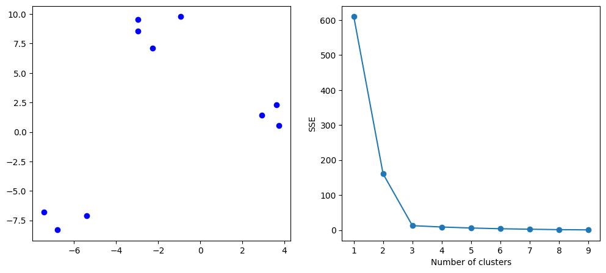

```python
import matplotlib.pyplot as plt
from sklearn.cluster import KMeans
from sklearn.datasets import make_blobs
import warnings
warnings.filterwarnings('ignore')

# 创建一个数据集，包含10个样本点，每个样本点有两个特征
X, y = make_blobs(n_samples=10, centers=3, n_features=2, random_state=42)

# 绘制样本点
plt.figure(figsize=(12,5))
plt.subplot(1,2,1)
plt.scatter(X[:, 0], X[:, 1], c='blue')

# 尝试不同的簇数，并计算相应的SSE
SSE = []
for k in range(1, 10):
    kmeans = KMeans(n_clusters=k)
    kmeans.fit(X)
    SSE.append(kmeans.inertia_)

# 绘制SSE与簇数的关系图
plt.subplot(1,2,2)
plt.plot(range(1, 10), SSE, marker='o')
plt.xlabel('Number of clusters')
plt.ylabel('SSE')
plt.show()
```

代码自动生成了10个样本，样本从图形上看很适合分成三类。  
根据聚类误差来看，当K从1到3变化时，聚类误差的下降速度非常快，但是当K从3到4时，SSE就没有发生明显的变化。  
因此根据肘部法则这个数据集更适合聚成3类。

## 七. 如何评价聚类算法的结果

1. 内部评价指标

这些指标基于聚类内部的数据分布，用于评估聚类算法的有效性和准确性。  
常用的内部评价指标包括轮廓系数、Calinski-Harabasz指数、Davies-Bouldin指数等。  
2. 外部评价指标  
这些指标基于已知的数据类别信息，如真实的类别标签，用于评估聚类算法的性能。常用的外部评价指标包括纯度、兰德指数、互信息等。  
3. 可解释性和可视化  
聚类算法不仅需要能够准确地将数据点分组，还需要对这些分组提供可解释的解释和可视化。  
4. 算法的可扩展性  
聚类算法应该能够处理大量数据，并且在处理大量数据时应该保持相对较快的运行速度。

等待后面有时间了补充，聚类算法结果的评价很重要...  
同时还有很多改进版本的聚类算法还等待补充。

# **数据挖掘第四章-数据挖掘基本算法一**

[figure not shown]

机器学习中的分类任务是一种监督学习任务，其目标是将输入数据分成预定义的几个类别中的一个或多个。  
分类任务基本上都属于有监督学习的范畴里面。  
在分类任务中，训练数据集包含了许多已经被标记了类别的样本数据，机器学习模型根据这些已知类别的样本数据来学习如何对未知数据进行分类。  
分类任务可以分为两类：二分类和多分类。

1. 二分类任务

这种任务将输入数据分为两个类别中的一个。例如，判断一封电子邮件是否是垃圾邮件或者是否是欺诈邮件。  
2. 多分类任务  
这种任务将输入数据分成多个类别中的一个。例如，图像识别问题中，将图像分类为人类、狗、猫或汽车等多个类别中的一个。

接下来就介绍几种机器学习中常见的分类算法。

## 一. KNN算法

K最近邻(K-Nearest Neighbors, KNN)是一种基于实例的监督学习算法，常用于分类和回归任务。  
KNN算法的基本思想是在训练数据集中找到与测试数据集最相似的K个样本，然后通过对这K个样本的类别进行投票来决定测试数据集的类别。  
KNN算法的优点是简单易懂、容易实现、适用于各种数据类型，例如离散型、连续型、多类别、多维度等。  
然而，KNN算法的缺点也很明显，首先需要大量的存储空间来存储训练数据集。  
其次计算距离是KNN算法的核心，需要对所有训练数据计算距离，计算复杂度较高。  
另外，在多维度空间中，KNN算法的距离计算也存在一定的问题，因为随着维度的增加，距离计算的效率和准确性都会受到影响。

[figure not shown]

**KNN算法步骤**  
计算待分类样本与训练数据集中每个样本之间的距离，常用的距离度量方法包括欧氏距离、曼哈顿距离等。  
选择与待分类样本距离最近的K个样本，这些样本被称为K个最近邻。  
根据K个最近邻的类别进行投票，将待分类样本归为投票得票最多的类别。K一般选择奇数。

**KNN算法案例**

假设我们有一个数据集，一共有5个样本，每个样本有2个特征，同时数据集还提供了标签数据label。

| x1 | x2 | label |
| --- | --- | --- |
| 1 | 1 | 0 |
| 2 | 2 | 0 |
| 3 | 3 | 1 |
| 4 | 4 | 1 |
| 5 | 5 | 1 |

这时候有一个没有标签的样本[6, 6]，需要我们判断一下这个样本属于哪一个类别。  
首先我们按照算法步骤，首先计算一下新样本与已知样本的距离，样本距离的度量采用欧式距离。

| new | old | distance |
| --- | --- | --- |
| [6, 6] | [1, 1] | 50 |
| [6, 6] | [2, 2] | 32 |
| [6, 6] | [3, 3] | 18 |
| [6, 6] | [4, 4] | 8 |
| [6, 6] | [5, 5] | 2 |

第二步，我们设定K=3，即选出与新样本距离最近的3个样本，让进行投票决定。  
与新样本距离最近的三个样本分别是[3, 3]、[4, 4]、[5, 5]。对应的标签为1，1，1。  
按照少数服从多数的原则，最终投票决定新样本的标签为1。

| x1 | x2 | y |
| --- | --- | --- |
| 1 | 1 | 0 |
| 2 | 2 | 0 |
| 3 | 3 | 1 |
| 4 | 4 | 1 |
| 5 | 5 | 1 |
| 6 | 6 | 1 |

**TIP**

这里K的选定一般都是选择奇数个，因为偶数可能会出现数量相同的情况。  
K值在实际中一般取3、5、7、9，也有100以上的情况。  
在具体数据集中可以采用交叉验证的方法来确定K具体取多少能达到较优的分类效果。  
距离公式选定的不同也会影响投票的结果，需要根据实际数据合理选择距离公式。  
这里可以后续继续补充完整。

## 二. 朴素贝叶斯算法

朴素贝叶斯算法（Naive Bayes）是一种基于贝叶斯定理和特征条件独立假设的分类算法。  
它的基本思想是，在给定一个新的样本特征值后，根据贝叶斯定理计算出该样本属于每个类别的概率，然后选取概率最大的类别作为该样本的分类。

朴素贝叶斯算法的主要假设是特征条件独立性，即假设每个特征在给定类别的条件下是独立的，即：

$$P(X=x| Y=c)=\prod_{i=1}^{m}P(X_i=x_i|Y=c)$$

其中，$X_i$表示样本的第$i$个特征，$x_i$表示该特征对应的取值，$Y$表示类别，$c$表示类别的取值。举个具体的例子：

$$P(X=(1,2,3) |Y=1)=P(X_1=1|Y=1) * P(X_2=2|Y=1) * P(X_3=3|Y=1)$$

根据贝叶斯定理，我们可以计算出样本属于某个类别$c$的后验概率$P(Y=c|X)$：
$$P(Y=c|X)=\frac{P(X|Y=c)P(Y=c)}{P(X)}$$
其中，$P(X|Y=c)$表示在类别$c$的条件下，样本$X$出现的概率；$P(Y=c)$表示类别$c$的先验概率；$P(X)$表示样本$X$的概率。

由于$P(X)$对于每个类别都是相同的，因此可以省略，得到：
$$P(Y=c|X) \propto P(X|Y=c)P(Y=c)$$
但是在实际情况中, $P(X)$ 是一个归一化因子，可以让样本属于各个类的概率总和为1。后面结合案例细讲。

我们可以计算出在给定类别$c$的条件下，样本$X$的概率$P(X|Y=c)$：
$$P(X|Y=c) = \prod_{i=1}^{m}P(X_i=x_i|Y=c)$$

根据训练集中的数据，可以估计出$P(X_i=x_i|Y=c)$和$P(Y=c)$的值，进而计算出$P(Y=c|X)$的值，  
从而得到样本$X$属于每个类别的后验概率，选取概率最大的类别作为该样本的分类。

在实际应用中，我们通常使用对数似然来计算$P(X|Y=c)$：
$$-\log P(X|Y=c) = -\sum_{i=1}^{n} \log P(X_i=x_i|Y=c)$$
这样可以避免连乘运算带来的下溢问题。

**朴素贝叶斯算法案例**

给定如下数据集：

| 性别 | 电影类型 | 喜欢电影 |
| --- | --- | --- |
| 男 | 动作片 | 是 |
| 女 | 喜剧片 | 是 |
| 女 | 爱情片 | 是 |
| 男 | 动作片 | 是 |
| 男 | 爱情片 | 否 |
| 女 | 动作片 | 否 |
| 女 | 喜剧片 | 否 |
| 女 | 动作片 | 否 |
| 男 | 爱情片 | 否 |
| 男 | 动作片 | 否 |

现在要根据用户的性别和喜欢的电影类型（动作片、喜剧片、爱情片）来预测用户是否喜欢某个电影。  
给定一个样本[男性, 动作片]，利用朴素贝叶斯算法来判断这个样本属于哪一个类别。

1. 计算每个类别的先验概率$P(Y)$

先验概率表示在没有任何其他信息的情况下，每个类别的出现概率。  
在本例中，样本有两个类别：喜欢电影（是）和不喜欢电影（否）。  
根据训练集中的数据，喜欢电影的先验概率$P(Y=是)$为0.4，不喜欢电影的先验概率$P(Y=否)$为0.6。  
2. 计算每个特征在各个类别下的条件概率$P(X_i|Y)$  
条件概率表示在已知类别的情况下，某个特征取某个值的概率。  
在本例中，有两个特征：性别和电影类型。  
对于性别特征，男性在喜欢电影的样本中出现了2次，总共有4个喜欢电影的样本，因此男性在喜欢电影的情况下的条件概率为$P(X_1=男性|Y=是)=2/4=0.5$，  
同理，男性在不喜欢电影的情况下的条件概率为$P(X_1=男性|Y=否)=0.5$。  
最终所有条件概率整理如下：  
$P(X_1=男性|Y=是)=0.5$  
$P(X_1=男性|Y=否)=0.5$  
$P(X_1=女性|Y=是)=0.5$  
$P(X_1=女性|Y=否)=0.5$  
$P(X_2=动作片|Y=是)=0.5$  
$P(X_2=爱情片|Y=是)=0.25$  
$P(X_2=喜剧片|Y=是)=0.25$  
$P(X_2=动作片|Y=否)=0.5$  
$P(X_2=爱情片|Y=否)=\frac{1}{3}$  
$P(X_2=喜剧片|Y=否)=\frac{1}{6}$  
3. 计算后验概率$P(Y|X)$（贝叶斯定理）  
$P(Y=是|X_1=男性, X_2=动作片)$  
$=\frac{P(X_1=男性, X_2=动作片|Y=是) \times P(Y=是)}{P(X_1=男性, X_2=动作片)} $  
$= \frac{P(Y=是) \times P(X_1=男性|Y=是) \times P(X_2=动作片|Y=是)}{P(X_1=男性, X_2=动作片|Y=是) + P(X_1=男性, X_2=动作片|Y=否)}$  
根据全概率公式  
$P(X_1=男性)$  
$=P(X_1=男性|Y=是) \times P(Y=是) + P(X_1=男性|Y=否) \times P(Y=否)$  
$=2/4 \times 4/10 + 3/6 \times 6/10 = 0.5 $  
同理  
$P(X_2=动作片)$  
$=P(X_2=动作片|Y=是) \times P(Y=是) + P(X_2=动作片|Y=否) \times P(Y=否)$  
$=2/4 \times 4/10 + 3/6 \times 6/10 = 0.5 $  
所以  
$P(Y=是|X_1=男性, X_2=动作片)$  
$= \frac{P(Y=是) \times P(X_1=男性|Y=是) \times P(X_2=动作片|Y=是)}{P(X_1=男性) \times P(X_2=动作片)}$  
$= \frac{4/10 \times 0.5 \times 0.5}{0.5 \times 0.5} = 0.4$  
$P(Y=否|X_1=男性, X_2=动作片)=1-P(Y=是|X_1=男性, X_2=动作片) = 0.6$

因此，根据朴素贝叶斯算法，我们可以预测该用户不会喜欢这个电影。

**TIP**

朴素贝叶斯算法的优点包括

1. 算法简单

朴素贝叶斯算法是一种简单有效的分类算法，易于理解和实现。  
2. 适用性广泛  
朴素贝叶斯算法适用于大量特征的分类问题，例如文本分类、垃圾邮件过滤等。  
3. 可解释性强  
朴素贝叶斯算法能够给出每个特征对分类结果的贡献，因此具有很好的可解释性。

朴素贝叶斯算法的缺点包括

1. 假设特征独立

朴素贝叶斯算法假设各个特征之间相互独立，但实际情况往往不是这样，因此可能会影响分类效果。  
2. 对数据分布有要求  
朴素贝叶斯算法假设数据服从特定的分布，例如正态分布、多项式分布等，如果数据分布不符合假设，可能会导致分类效果下降。  
3. 处理连续特征需要离散化  
朴素贝叶斯算法处理连续特征需要先将其离散化，可能会导致信息损失和精度降低。

## 三. 决策树算法

决策树是一种常用的机器学习算法，可以用于分类和回归问题。  
它的主要思想是根据数据特征的不同，将数据集分割成多个小的子集，直到每个子集都只包含同一类别的数据，或者达到一定的停止条件。  
这样就可以构建出一棵树形结构，每个叶子节点表示一种类别或者一个回归值，每个中间节点表示一个特征及其取值范围。  
通过在树上从根节点到叶子节点的路径上进行特征判断，就可以对新数据进行分类或回归。

[figure not shown]

假设决策树有M个叶子结点，那么决策树的函数形式可以表示成如下形式：

$$f(x) = \sum_{m=1}^{M}c_{m}I(x\in R_{m})$$

**决策树算法基本步骤**

1. 特征选择

从所有特征中选择一个最优特征，用于对数据集进行划分。常用的特征选择方法有信息增益、信息增益比、基尼指数等。  
2. 决策树的生成  
根据选定的特征进行数据集的划分，每个分支对应特征的一个取值，直到每个分支的样本都属于同一类别或者满足一定的停止条件为止。  
常用的停止条件包括树的深度、叶子节点中样本数的最小值等。  
3. 决策树的剪枝  
为了防止决策树出现过拟合现象，需要对决策树进行剪枝。  
常用的剪枝方法有预剪枝和后剪枝。预剪枝是在生成决策树时进行剪枝，后剪枝是在生成完整的决策树后再进行剪枝。

### 3.1 决策树的特征选择

回忆高中化学讲过的熵的概念，一个系统越混乱熵越大，越简洁熵越小。  
决策树的思想很明显是想让数据集分而治之，让整体数据集的分布更加简洁的。

**1. 信息增益**
信息增益（information gain）是一种常用的特征选择方法，它的基本思想是选择能够带来最大信息增益的特征作为划分依据。信息增益的定义如下：
$$ IG(D, f) = H(D) - H(D|f) $$
其中，$D$表示数据集，$f$表示特征，$H(D)$表示数据集$D$的经验熵，$H(D|f)$表示特征$f$对数据集$D$的经验条件熵。
经验熵$H(D)$的定义如下：
$$ H(D) = - \sum_{k=1}^{|y|} \frac{|C_k|}{|D|} \log_2 \frac{|C_k|}{|D|} $$
其中，$|y|$表示类别的个数，$|C_k|$表示属于第$k$个类别的样本数。
经验条件熵$H(D|f)$的定义如下：
$$ H(D|f) = \sum_{i=1}^n \frac{|D_i|}{|D|} H(D_i) $$
其中，$n$表示特征$f$的取值个数，$D_i$表示特征$f$取值为$i$的样本子集。
因此，特征$f$的信息增益$IG(D, f)$越大，则表明特征$f$越重要。

**信息增益计算案例**

给定数据，其中，Feature 1 和 Feature 2 是样本的两个特征，Label 是该样本的类别，0 表示负样本，1 表示正样本。：

| ID | Feature 1 | Feature 2 | Label | | --- | --- | --- | --- | | 1 | 1 | 0 | 0 | | 2 | 1 | 1 | 0 | | 3 | 1 | 0 | 0 | | 4 | 0 | 1 | 0 | | 5 | 0 | 1 | 1 | | 6 | 0 | 0 | 1 | | 7 | 1 | 1 | 1 |

首先，计算数据集的熵：
$$H(D) = -\sum_{i=1}^{2}\frac{count(y=i)}{|D|}\log_2\frac{count(y=i)}{|D|}$$
其中，$count(y=i)$ 表示样本中类别为 $i$ 的数量，$|D|$ 表示样本总数。代入数据集，可以得到：
$$H(D) = -\frac{4}{7}\log_2\frac{4}{7} - \frac{3}{7}\log_2\frac{3}{7} \approx 0.985$$

| ID | Feature 1 |Feature 2 | Label | | --- | --- |--- | --- | | 1 | 1 | 0 | 0 | | 2 | 1 | 1 | 0 | | 3 | 1 | 0 | 0 | | 7 | 1 | 1 | 1 |

[output not shown]

**2. 信息增益比**
信息增益比是对信息增益的一种修正，信息增益倾向于选取那些特征取值非常多的特征作为划分节点，信息增益比克服了这种倾向。
它的基本思想是将信息增益除以特征$f$的固有值，以消除特征取值个数对信息增益的影响。
信息增益比的定义如下：
$$ IG_R(D, f) = \frac{IG(D, f)}{IV(f)} $$
其中，$IV(f)$表示特征$f$的固有值，定义如下：
$$ IV(f) = - \sum_{i=1}^n \frac{|D_i|}{|D|} \log_2 \frac{|D_i|}{|D|} $$
也可以直接把 $ IV(f) $ 理解成特征 $f$ 的熵。
因此，特征$f$的信息增益比$IG_R(D, f)$越大，则表明特征$f$越重要。

**信息增益比计算案例**

| ID | Feature 1 | Feature 2 | Label | | --- | --- | --- | --- | | 1 | 1 | 0 | 0 | | 2 | 1 | 1 | 0 | | 3 | 1 | 0 | 0 | | 4 | 0 | 1 | 0 | | 5 | 0 | 1 | 1 | | 6 | 0 | 0 | 1 | | 7 | 1 | 1 | 1 |

重点在于计算 $IV(Feature1)$ 和 $IV(Feature2)$  
$Feature1$ 一共有两种取值，分别是0和1,0的个数是3个，1的个数是4个，总共有7个样本。  
带入公式计算：  
$ IV(Feature1) = -(\frac{3}{7}\log_2\frac{3}{7} + \frac{4}{7}\log_2\frac{4}{7})$  
同理可以计算 $Feature2$ 的固有值。  
$ IV(Feature2) = -(\frac{3}{7}\log_2\frac{3}{7} + \frac{4}{7}\log_2\frac{4}{7})$

然后就可以继续计算信息增益比来决定选择哪一个特征是最优的划分特征。

**3. 基尼系数**
基尼指数是一种用于衡量数据集纯度的指标，它的定义如下：
$$Gini(p)=\sum_{k=1}^{K}p_k(1-p_k)$$
请读者自行推导：在二分类情况下基尼系数的写法。
其中，$p_k$ 是数据集中第 $k$ 类样本占总样本数的比例，$K$ 是分类数目。

在决策树算法中，基尼系数被用于选择最优划分特征，计算公式如下：
$$ Gini(D, a)=\sum_{v=1}^{V}\frac{|D^v|}{|D|}Gini(D^v) $$

| ID | Feature 1 | Feature 2 | Label | | --- | --- | --- | --- | | 1 | 1 | 0 | 0 | | 2 | 1 | 1 | 0 | | 3 | 1 | 0 | 0 | | 4 | 0 | 1 | 0 | | 5 | 0 | 1 | 1 | | 6 | 0 | 0 | 1 | | 7 | 1 | 1 | 1 |

仍然是以该数据集来演示计算，首先计算整体数据集的基尼系数。

$$ Gini(D)=1-(\frac{3}{7})^2-(\frac{4}{7})^2=0.4898 $$

### 3.2 决策树的生成

基本的决策树生成算法有三种：ID3、C4.5、CART算法，算法内容可以参考以下博客。  
Reference: https://blog.csdn.net/kafei110/article/details/125585665  
ID3计算案例：https://blog.csdn.net/weixin_46245411/article/details/114703474

**ID3算法**  
ID3算法是一种经典的决策树算法，用于在给定数据集中生成决策树。该算法是基于信息熵和信息增益的原理进行特征选择，以对数据集进行划分。  
**ID3算法步骤**

1. 计算数据集中每个特征的信息增益，选择信息增益最大的特征作为当前节点的分裂特征。
2. 根据分裂特征，将数据集分为若干个子集，对每个子集递归地执行步骤1和步骤2，直到满足迭代停止的条件为止。
3. 最终生成的决策树可以通过遍历决策树对新样本进行分类。

对于ID3算法不再提供具体的算例了，后面时间充裕可以补充一个例子。  
简单的说明一下ID3算法，首先第一步的时候根据信息增益来选择特征肯定很简单了。  
第一步结束后，我们就可以根据选择的特征画出第一层的决策树。  
在画出第一层决策树后，决策树的每一个叶子节点上都分布了不同数量的数据集。  
然后在生成第二层决策树的时候，数据集就变成了每一个叶子节点上的数据集了，对叶子节点上的小数据继续用信息增益的法则进行特征选择和分裂。  
还有一个细节就是根据ID3算法生成出来的决策树不是二叉树，多少叉取决于我们选择出来的特征，比如三叉四叉都有可能。

**C4.5算法**  
C4.5算法是决策树算法中的一种，与ID3算法相似，但对ID3算法中的一些问题进行了改进，是一种更为高级的决策树算法。  
C4.5算法在ID3算法的基础上进行了以下改进

1. 处理缺失值

C4.5可以处理缺失值，而ID3无法处理缺失值。当样本在某个特征上缺失值时，C4.5会按照该特征在所有样本中出现的概率随机赋值。  
2. 采用信息增益比  
C4.5采用信息增益比来选择最优特征，而不是仅仅使用信息增益，信息增益比可以对可取值数目多的特征进行惩罚。  
3. 连续值处理  
C4.5可以处理连续值特征，它会通过二分法将连续值离散化。  
**C4.5算法步骤**

1. 使用信息增益比（gain ratio）来度量每个特征的重要性，选择信息增益比最大的特征作为当前节点的分裂特征。
2. 根据分裂特征将数据集分为不同的子集，递归生成子树。
3. 使用交叉验证来判断是否剪枝，避免决策树过拟合。
4. 决策树输出：输出生成的决策树模型。

但是还是可以看出来C4.5的算法依然是多叉树。

**CART算法**  
CART（Classification and Regression Trees）是一种常见的决策树算法，可以用于分类和回归问题。  
与 ID3 和 C4.5 算法不同，CART 算法是一种二叉树算法，每个节点只有两个子节点。  
CART 算法通过选择最优特征和最优切分点来划分数据集，使得每个子节点内的样本尽可能属于同一类别或拥有较小的回归方差。  
CART 算法在分类问题中使用基尼指数（Gini index）来衡量数据集的纯度，计算特征的信息增益，从而选择最优划分。  
CART 算法的生成过程可以简述为:

1. 遍历所有特征，对每个特征进行切分点的选择，并计算基尼指数；
2. 选择基尼指数最小的特征和切分点，将数据集分成两部分；
3. 对于分出的两个数据子集，重复执行 1 和 2 步骤，直到满足停止条件；
4. 从下往上合并节点，并进行剪枝操作，以避免过拟合。

CART 算法与 ID3 和 C4.5 算法相比，其优点是生成的决策树具有更高的精度和更快的训练速度，缺点是生成的决策树可能过于复杂，容易过拟合。

**CART生成案例**

数据集来源：统计学习方法--李航

|  | age | have_job | have_house | loan_situation | label |
| --- | --- | --- | --- | --- | --- |
| 0 | 青年 | 否 | 否 | 一般 | 0 |
| 1 | 青年 | 否 | 否 | 好 | 0 |
| 2 | 青年 | 是 | 否 | 好 | 1 |
| 3 | 青年 | 是 | 是 | 一般 | 1 |
| 4 | 青年 | 否 | 否 | 一般 | 0 |
| 5 | 中年 | 否 | 否 | 一般 | 0 |
| 6 | 中年 | 否 | 否 | 好 | 0 |
| 7 | 中年 | 是 | 是 | 好 | 1 |
| 8 | 中年 | 否 | 是 | 非常好 | 1 |
| 9 | 中年 | 否 | 是 | 非常好 | 1 |
| 10 | 老年 | 否 | 是 | 非常好 | 1 |
| 11 | 老年 | 否 | 是 | 好 | 1 |
| 12 | 老年 | 是 | 否 | 好 | 1 |
| 13 | 老年 | 是 | 否 | 非常好 | 1 |
| 14 | 老年 | 否 | 否 | 一般 | 0 |

```python
# 这个是预处理之后的数据集，想进入数学模型还是得把分类型变量做一定的编码
df
```

|  | age | have_job | have_house | loan_situation | label |
| --- | --- | --- | --- | --- | --- |
| 0 | 0 | 0 | 0 | 0 | 0 |
| 1 | 0 | 0 | 0 | 1 | 0 |
| 2 | 0 | 1 | 0 | 1 | 1 |
| 3 | 0 | 1 | 1 | 0 | 1 |
| 4 | 0 | 0 | 0 | 0 | 0 |
| 5 | 1 | 0 | 0 | 0 | 0 |
| 6 | 1 | 0 | 0 | 1 | 0 |
| 7 | 1 | 1 | 1 | 1 | 1 |
| 8 | 1 | 0 | 1 | 2 | 1 |
| 9 | 1 | 0 | 1 | 2 | 1 |
| 10 | 2 | 0 | 1 | 2 | 1 |
| 11 | 2 | 0 | 1 | 1 | 1 |
| 12 | 2 | 1 | 0 | 1 | 1 |
| 13 | 2 | 1 | 0 | 2 | 1 |
| 14 | 2 | 0 | 0 | 0 | 0 |

```python
import numpy as np
import pandas as pd
from sklearn.tree import DecisionTreeClassifier,export_graphviz
from sklearn.metrics import mean_squared_error as MSE
from graphviz import Source

df = pd.DataFrame()
df['age'] = ['青年', '青年', '青年', '青年', '青年',
             '中年', '中年', '中年', '中年', '中年',
             '老年', '老年', '老年', '老年', '老年']
df['have_job'] = ['否', '否','是', '是','否',
                  '否','否','是','否','否',
                  '否','否','是','是','否']
df['have_house'] = ['否', '否','否', '是','否',
                  '否','否','是','是','是',
                  '是','是','否','否','否']
df['loan_situation'] = ['一般', '好', '好', '一般','一般',
                        '一般','好','好','非常好','非常好',
                       '非常好','好','好','非常好','一般']
df['label'] = [0,0,1,1,0,
              0,0,1,1,1,
              1,1,1,1,0]

df['age'] = df.age.apply(lambda x: 0 if x == '青年'
                         else(1 if x == '中年'
                         else(2)))
df['have_job'] = df.have_job.apply(lambda x: 0 if x == '否' else 1)
df['have_house'] = df.have_house.apply(lambda x: 0 if x == '否' else 1)
df['loan_situation'] = df.loan_situation.apply(lambda x: 0 if x == '一般'
                         else(1 if x == '好'
                         else(2)))

model = DecisionTreeClassifier(criterion='gini',splitter='best')
model.fit(df.iloc[:,0:4], df.iloc[:, 4])

dot_file = export_graphviz(model, out_file=None)
Source(dot_file)
```

[figure not shown]

## 四. 分类算法的评价指标

我们已经学习了三个基本的分类算法，那么很自然的就会涉及到算法效果之间的比较，因此需要有指标去衡量这些算法。

机器学习中分类算法的评价指标有很多，下面是一些常用的指标：

1. 精确度（Accuracy）

指分类器正确分类的样本数与总样本数的比例，是最常用的分类器性能指标之一。但是，当样本不平衡时，精度可能会误导我们。  
比如一个样本不平衡的数据集中，正类样本有9个，负类样本有1个，我不用模型预测，盲猜全部都为正类也有90%的正确率。  
2. 精确率（Precision）  
指被分类器正确分类为正样本的样本数与被分类器分类为正样本的样本总数的比例。精确率评估了分类器对正样本的判断能力，是一种很常见的评价指标。  
3. 召回率（Recall）  
指被分类器正确分类为正样本的样本数与实际正样本总数的比例。召回率评估了分类器发现正样本的能力。  
4. F1值（F1 score）  
指的是精确率和召回率的调和平均数，综合考虑了精确率和召回率。F1值的范围在0和1之间，值越高表示分类器性能越好。  
5. ROC曲线和AUC  
ROC曲线是以假正例率（false positive rate）为横坐标，真正例率（true positive rate）为纵坐标的曲线，展示了分类器在不同阈值下的性能。  
AUC（Area Under the Curve）是ROC曲线下的面积，表示分类器在不同阈值下的平均性能。

这些指标可以根据不同的应用场景和数据特征选择不同的优化策略。  
例如，在一些需要高精确度的场景中，可以选择优化精度，而在另一些需要高召回率的场景中，可以选择优化召回率。

首先要引入混淆矩阵的概念。

| | 预测为正例P | 预测为负例N | | --- | :---: | :---: | | 实际为正例 | TP | FN | | 实际为负例| FP | TN |

其中，TP表示将正例预测为正例的样本数，FP表示将负例预测为正例的样本数，FN表示将正例预测为负例的样本数，TN表示将负例预测为负例的样本数。

通过混淆矩阵，我们可以计算出上述指标：  
精确度（Accuracy）= (TP + TN) / (TP + TN + FP + FN)  
精准率（Precision）= TP / (TP + FP)  
召回率（Recall）= TP / (TP + FN)  
F1值（F1 score）= $\frac{2}{ (\frac{1} {Precision}) + (\frac{1}{Recall})} $= 2 * Precision * Recall / (Precision + Recall)  
ROC曲线和AUC：可以通过计算不同阈值下的TPR和FPR，绘制ROC曲线并计算AUC。  
精确度是五个指标中最好理解的一个指标，精确度就是判断正确的样本占样本总体的比例，比较容易混淆的是精准率和召回率这两个指标。

**首先明确：**不管是精准率还是召回率，这两个指标衡量的都是模型分辨正样本的能力，只不过角度不同。  
对于精准率，我们可以理解为将样本正确分类为正例的能力，即在所有预测为正例的样本中，有多少是真正的正例。  
对于医疗机构，可能会追求更高的精准度，有的疾病如果病人没病，但是被你预测为有病，比如癌症艾滋，这种社会影响就会很严重。  
对于召回率，我们可以理解为找出正例的能力，即在所有真正的正例中，有多少被正确找出。  
对于汽车企业，可能会追求更高的召回率（此召回非彼召回），因为一个有问题的车如果在出厂前没有被模型预测出来，就会带来后续高额的售后成本。  
**口诀：横召竖精**

但是大部分情形我们追求的是精准率和召回率都要达到较高水平，因此就引入的F1值。  
如果想要达到较高的F1值，模型的精准率和召回率都必须达到较高的水平。  
精确率、精准率、召回率、F1值都是基于混淆矩阵来判断的，但是混淆矩阵需要给定一个具体的分类阈值才可以得出。  
ROC曲线则是基于滑动阈值得出的图形，对于模型的预测能力评价更加全面。  
对于ROC曲线的讲解就结合在下面这个具体案例里面讲解吧。

**分类算法评价指标计算案例**

假设我们有7个样本，对应的真实标签和模型的预测概率如下表所示：

| ID | true_label | predict_prob | | :---: | :---: | :---: | | 1 | 1 | 0.4 | | 2 | 1 | 0.6 | | 3 | 1 | 0.3 | | 4 | 0 | 0.1 | | 5 | 0 | 0.1 | | 6 | 0 | 0.1 | | 7 | 1 | 0.6 |

然后我们人为给定一个阈值，比如说概率小于0.5就认为是负类样本，大于等于0.5就是正类样本。  
这样我们就可以根据这个规则去计算模型预测标签了,结果如下表所示。

| ID | true_label | predict_label | | --- | :---: | :---: | | 1 | 1 | 0 | | 2 | 1 | 1 | | 3 | 1 | 0 | | 4 | 0 | 0 | | 5 | 0 | 0 | | 6 | 0 | 0 | | 7 | 1 | 1 |

有了真实标签与模型预测标签之后就可以计算混淆矩阵：

| | 预测为正例 | 预测为负例 | | --- | :---: | :---: | | 实际为正例 | 2 | 2 | | 实际为负例 | 0 | 3 |

然后就可以对应计算精确率、精准率、召回率、F1值：  
精确率：2+3 / 2+2+3  
召回率: 2 / 2+2  
精准率：2 / 2+0  
F1: 2 /（1+2）= 2/3

不过混淆矩阵需要我们认为给定阈值才可以求出来，ROC曲线则是滑动阈值，通过动态给定阈值来绘制出一条TPR和FPR的曲线。  
其中TPR是TP占真实正样本的比例，FPR是FP占真实负样本的比例。

| 阈值 | TPR | FPR | | --- | :---: | :---: | | 0.3 | 1 | 0 | | 0.5 | 0.5 | 0 | | 0.8 | 0 | 0 |

只要给定足够多的阈值就可以画出一条$TPR$--$FPR$的曲线，如下图的模样。

[figure not shown]

## 五. 过拟合和欠拟合

在机器学习中，过拟合和欠拟合是两种常见的问题，它们可能会导致模型的性能下降。  
过拟合（Overfitting）指的是模型在训练集上表现得很好，但是在测试集上表现不佳的现象。  
过拟合通常是由于模型的复杂度过高，在训练集上学习了过多的细节和噪声，导致模型对训练集过度拟合，从而泛化能力不足。  
欠拟合（Underfitting）指的是模型在训练集上和测试集上都表现不佳的现象。  
欠拟合通常是由于模型的复杂度过低，在训练集上学习的模式过于简单，无法捕捉数据的复杂关系，从而导致模型无法正确地进行预测。  
过拟合和欠拟合的状态如下图所示：

[figure not shown]

第一张图是模型学习对于变量之间非线性关系的学习能力比较弱，所以出现了很多点被分错的情况。  
学习能力弱模型不管是在训练数据集上，还是说未知数据上（比如说测试集上）都不会有较高的指标得分。  
第三张图的模型对于变量之间非线性关系的学习能力非常强，九曲十八弯，把数据全部都分类正确了。  
虽然复杂模型对于训练数据的拟合程度很好，但是由于过于复杂，导致在未知的数据集上，预测能力反而变弱了。  
好的拟合如第二张图所示，虽然有一定的错误分类，但是不管是训练数据集还是未知的数据集上，该模型都会有鲁棒性(robust)的表现。  
在机器学习中，我们在追求模型有较强的拟合能力的同时，也会注重模型的泛化能力，这两种能力是需要互相取舍的。  
对于过拟合和欠拟合，通常也会说模型有高偏差(high bias)和高方差(high variance)。

**解决过拟合的方法：**

1. 数据集扩充（Data Augmentation）

通过旋转、翻转、裁剪等方式增加训练集的大小，从而减少过拟合的风险。  
2. 正则化（Regularization）  
通过加入正则化项（如L1正则化、L2正则化）来限制模型的复杂度，从而减少过拟合的风险。  
3. 提前终止（Early Stopping）  
在训练过程中，根据验证集的性能来决定何时停止训练，从而避免过拟合。  
4. 模型集成（Ensemble）  
通过将多个不同的模型集成起来，以获得更好的泛化能力。常见的模型集成方法有投票法、平均法、堆叠法等。  
5. 特征选择（Feature Selection）  
通过选择对目标变量有较大影响的特征，减小模型的复杂度，防止过拟合。  
6. 贝叶斯优化（Bayesian Optimization）  
通过优化模型的超参数，获得更好的模型性能，防止过拟合。

这些方法并不是独立的，常常需要在实际应用中进行组合使用。在选择方法时，需要考虑问题的具体情况，选择最适合的方法来解决过拟合问题。

**解决欠拟合的方法：**  
增加模型复杂度：增加模型中的神经元数量、网络深度、层数等等，以提高模型的表达能力，从而更好地拟合训练数据。

改变模型结构：更改模型的架构，选择不同的激活函数、损失函数、优化算法等等，以提高模型的拟合能力。

1. 数据集扩充

增加更多的训练数据可以提高模型的泛化能力，降低过拟合的风险，从而解决欠拟合问题。  
2. 特征工程  
通过对特征的选择、组合、归一化等方法，改进模型输入的数据质量，以提高模型的拟合能力。  
3. 模型集成  
通过将多个模型集成起来，得到更强的拟合能力。常见的集成方法有bagging、boosting等。  
4. 更换模型  
选择更适合数据分布和任务的模型，如决策树、随机森林、支持向量机等。

在实际应用中，解决欠拟合问题的方法往往是与解决过拟合问题的方法相对应的。  
例如，增加训练数据和特征工程可以同时解决过拟合和欠拟合问题。同时，增加模型复杂度和模型集成可能会导致过拟合的问题。  
需要根据实际情况综合考虑并选择适合的方法来解决欠拟合问题。并且过拟合和欠拟合往往是一对矛盾的问题。  
在训练过程中，需要通过交叉验证等方式来平衡模型的拟合能力和泛化能力，以提高模型的性能。

## 六. 训练模型的基本步骤

训练机器学习模型的基本步骤包括：

1. 收集数据

根据需要收集用于训练模型的数据。  
2. 数据预处理  
对数据进行清洗、去重、缺失值填充、特征缩放、特征选择等处理，以提高模型训练的效果。  
3. 划分数据集  
将数据集划分为训练集、验证集和测试集，用于训练模型、调整模型参数和测试模型性能。  
4. 选择合适的模型  
选择适合问题的模型，并根据数据集的特点和需求来确定模型的复杂度。  
5. 模型训练  
使用训练数据集训练模型，并通过不断地调整模型参数来提高模型的性能。  
6. 模型验证和调参  
使用验证数据集评估模型的性能，并根据评估结果调整模型参数，直至达到预期的性能。  
7. 模型测试  
使用测试数据集评估模型的泛化能力，检查模型是否能够正确地处理新的数据。  
8. 模型部署  
将训练好的模型部署到实际应用中，并进行持续的监控和维护，以保证模型的高质量和可靠性。

大部分步骤到目前为止其实多多少少都有涉及到了，但是数据集划分这块还没涉及到太多，所以在这里进行补充。

**数据集划分的方法**

数据集划分是机器学习中非常重要的一个步骤，它将数据集分成训练集、验证集和测试集等部分，以评估模型的性能和泛化能力。  
下面介绍一些常用的数据集划分方法：

1. 简单随机划分

将数据集随机地分成训练集和测试集，比例通常为70%-30%或80%-20%。  
这种方法适用于数据量较大的情况，但可能会导致训练集和测试集的分布不一致。  
2. 分层随机划分  
在简单随机划分的基础上，按照类别或标签等特征进行分层，以确保训练集和测试集的分布相似。  
这种方法适用于数据集中包含不同类别或标签的情况。  
3. K折交叉验证  
将数据集分成K个部分，依次使用其中K-1个部分作为训练集，剩下的一个部分作为测试集，重复K次，以得到平均测试误差。  
这种方法适用于数据量较少的情况，但会增加训练时间和计算成本。  
4. 留一交叉验证  
是K折交叉验证的一种特殊情况，即将数据集分成N个部分，每次使用其中一个部分作为测试集，其余部分作为训练集。  
这种方法适用于数据集非常小的情况，但会增加计算成本。  
5. 时间序列划分  
对于时间序列数据集，通常采用滑动窗口或滚动预测等方法进行划分，以确保测试集中包含模型训练之后的最新数据。  
这种方法适用于时间序列数据集的建模和预测。

以上是常用的数据集划分方法，根据数据集的特点和建模需求，可以选择合适的划分方法。

**划分数据集实际案例**

假设我们有10条数据。

| ID | x1 | label | | :---: | :---: | :---: | | 1 | 1 | 1 | | 2 | 1 | 1 | | 3 | 1 | 1 | | 4 | 0 | 0 | | 5 | 0 | 0 | | 6 | 0 | 0 | | 7 | 1 | 0 | | 8 | 1 | 1 | | 9 | 1 | 1 | | 10| 1 | 1 |

随机划分的训练集(2 - 8分)的结果:

| train_id | x1 | label | | :---: | :---: | :---: | | 1 | 1 | 1 | | 3 | 1 | 1 | | 4 | 0 | 0 | | 5 | 0 | 0 | | 6 | 0 | 0 | | 7 | 1 | 0 | | 9 | 1 | 1 | | 10| 1 | 1 |

| test_id | x1 | label | | :---: | :---: | :---: | | 2 | 1 | 1 | | 8 | 1 | 1 |

5折交叉验证的结果：  
每一折数据都会有一个评价结果，然后取平均值。

| fold | train_id | test_id | | :---: | :---: | :---: | | 1 | [1,2,3,4,5,6,7,8] | [9,10] | | 2 | [1,2,3,4,5,6,9,10] | [7,8] | | 3 | [1,2,3,4,7,8,9,10] | [5,6] | | 4 | [1,2,5,6,7,8,9,10] | [3,4] | | 5 | [3,4,5,6,7,8,9,10] | [1,2] |

比如说给我原始的10行的数据集，然后让我去训练一个决策树模型。  
首先我会二八分划分数据集，我们会用训练集去训练决策树模型，然后用测试集来检验决策树模型的效果。  
如果说出现过拟合或者欠拟合的情况，我们就会在训练集上调整决策树的参数，或者说做特征工程来提高模型的泛化能力。  
随机划分可能会出现随机性的情况，因此更稳健的方法是用K折交叉验证去调整模型，但是相对的会更耗费时间。

# **数据挖掘第五章-数据挖掘基本算法二**

[figure not shown]

当我们需要预测一个连续变量的值时，回归问题就变得非常重要。在数据挖掘中，回归问题通常是指通过一个或多个自变量来预测一个连续的因变量。  
回归问题可以被认为是在寻找自变量和因变量之间的关系。这种关系可以用一个函数或模型来表示，这个模型可以用来预测未知的因变量值。  
回归模型通常可以是线性的或非线性的，并且可以用许多不同的算法来训练和优化。  
一些常见的回归算法包括：

1. 线性回归

基于线性模型，寻找一个线性函数来拟合数据并进行预测。  
2. 多项式回归  
基于多项式模型，通过将自变量的幂添加到模型中来捕获非线性关系。  
3. 支持向量回归  
基于支持向量机（SVM）算法，寻找一个最小化预测误差的线性或非线性超平面。  
4. 决策树回归  
基于决策树算法，将数据集分割成多个子集，并在每个子集中构建一个回归模型。  
...

回归问题的应用广泛，例如金融预测、销售预测、医疗诊断和天气预报等。

## 一. 线性回归

线性回归（linear regression）是一种常见的回归算法，用于寻找自变量和因变量之间的线性关系。它通过拟合一个线性模型来预测未知的因变量值。
线性回归的数学形式可以表示为：
$$y = \beta_0 + \beta_1x_1 + \beta_2x_2 + ... + \beta_nx_n + \epsilon$$
其中，$y$是因变量,是样本的真实值，$x_1, x_2, ..., x_n$是自变量，$\beta_0, \beta_1, \beta_2, ..., \beta_n$是回归系数，$\epsilon$是随机误差项。
$$\hat{y}= \beta_0 + \beta_1x_1 + \beta_2x_2 + ... + \beta_nx_n $$
$\hat{y}$ 是模型的预测值。

[figure not shown]

| id | $$x_1$$ | y | $\hat{y}$ |
| --- | --- | --- | --- |
| 0 | 1 | 2 | 1.5 |
| 1 | 2 | 4 | 3 |
| 2 | 3 | 6 | 4.5 |

在线性回归中，最常用的损失函数是均方误差（Mean Squared Error，MSE）。均方误差是预测值和实际值之间差异的平方的平均值。
假设我们有 $n$ 个样本，第 $i$ 个样本的实际值为 $y_i$，预测值为 $\hat{y_i}$，则均方误差可以表示为：
$$MSE = \frac{1}{n} \sum_{i=1}^{n}(y_i - \hat{y_i})^2$$
其中$\hat{y_i} = \beta_0 + \beta_1x_1 + \beta_2x_2 + ... + \beta_nx_n$
线性回归的目标是最小化均方误差，即找到一组回归系数，使得预测值和实际值之间的均方误差最小化：
$$\min_{\beta} MSE$$
这个过程可以使用梯度下降法等优化算法来实现，之前高中或者本科基本就是直接给你一个死公式，硬背求解，这种套路在现实问题面前肯定是不够用的。

**梯度下降法**

假设我们要最小化函数 $y=x^2$
我们可以使用梯度下降算法来找到最小值。
首先，我们需要计算函数的导数，即梯度。在本例中，函数的梯度为：
$$\nabla y = \frac{\partial y}{\partial x} = 2x$$
然后，我们可以随机初始化一个起始点 $x_0$，然后迭代更新该点，直到达到收敛条件。每次迭代的更新公式为：
$$x_{i+1} = x_i - \alpha \nabla y(x_i)$$
其中，$\alpha$ 是学习率，用来控制每次更新的步长。
在每一步中，我们计算当前点的梯度值，然后将其乘以学习率，得到一个更新的方向和大小，最后将其从当前点中减去，得到下一个点。
这个过程不断迭代，直到满足收敛条件。

假设我们的初始点 $x_0=2$， $\alpha=0.1$, 然后用梯度下降法去寻找最小值点。

| 步骤 | $x$ | $grad$| $x$ - $\alpha$ *$grad$| |:---:| :---: |:---:|:---:| |1 |2 |4| 1.6| |2 |1.6 |3.2| 1.28| |3 |1.28 |2.56| 1.024| |4 |1.024 |2.048| 0.8192| |5 |0.8192 |1.6384| 0.65536| |6 |0.6554 |1.3107| 0.52429| |7 |0.5243 |1.0486| 0.41943| |8 |0.4194 |0.8389| 0.33554| |9 |0.3355 |0.6711| 0.26843| |10 |0.2684 |0.5369| 0.21475|

[figure not shown]

**线性回归实际算例**

我们有如下潦草的数据集:

| x | y |
| --- | --- |
| 1 | 2 |
| 2 | 4 |
| 3 | 6 |

目标就是拟合一条线性回归方程出来。
$$\hat{y} = \beta x $$
然后找到一个参数 $\beta$ 让下面的损失函数最小化。
$$\min_{\beta} COST = \frac{1}{2n} \sum_{i=1}^{n} (y_i - \hat{y_i})^2 $$
$$= \frac{1}{2n} \sum_{i=1}^{n} (y_i - \beta x_i)^2 $$

然后我们首先计算 $COST$的梯度：
$$\nabla COST = \frac{\partial COST}{\partial \beta} = -\frac{1}{n} \sum_{i=1}^{n} (y_i - \beta x_i)x_i$$

我们可以初始化 $\beta = 0$，$\alpha = 0.1$, 然后用梯度下降法进行计算。

[output not shown]

经过一定步骤的迭代，我们的 $\beta$ 就会无限趋近于2，也就是我们的最优解。

因此，我们可以认为设定迭代100轮停止，或者说迭代前后的 $\beta$ 值相差在0.0001以内时就停止。

**回归问题的评价指标**

在回归问题中，我们需要对模型的预测结果进行评估，以了解模型的性能。常用的回归问题的评价指标有以下几种

1. 均方误差 (Mean Squared Error, MSE)

均方误差是预测值与真实值差值的平方和的均值，表示预测值与真实值之间的差异程度。均方误差越小，说明模型的预测结果越接近真实值。
$$ MSE = \frac{1}{n} \sum_{i=1}^{n}(y_i - \hat{y_i})^2 $$
其中，$n$ 是样本数量，$y_i$ 是第 $i$ 个样本的真实值，$\hat{y_i}$ 是模型对第 $i$ 个样本的预测值。
2. 均方根误差 (Root Mean Squared Error, RMSE)
均方根误差是均方误差的平方根，与均方误差相比，均方根误差对误差大的样本更加敏感。
对于均方误差 (MSE) 而言，对误差大的样本也是更加敏感的，
因为它会将所有样本的误差平方后进行求和，而误差大的样本会对总误差的值产生更大的贡献。
但是，均方根误差 (RMSE) 与 MSE 不同，RMSE 首先对每个样本的误差进行平方，然后将所有样本的平方误差相加，
并进行平均和开方操作，因此更加关注每个样本的绝对误差大小，即平方根后的误差值。
因此，RMSE 在误差较大的样本上会更加敏感，因为误差较大的样本平方根后的误差值更大，会对 RMSE 计算结果产生更大的影响。
$$ RMSE = \sqrt{\frac{1}{n} \sum_{i=1}^{n}(y_i - \hat{y_i})^2} $$
3. 平均绝对误差 (Mean Absolute Error, MAE)
平均绝对误差是预测值与真实值差值的绝对值的均值，与均方误差相比，平均绝对误差更加关注误差的绝对大小，而不是误差的平方。
$$ MAE = \frac{1}{n} \sum_{i=1}^{n}|y_i - \hat{y_i}| $$
4. 决定系数 (Coefficient of Determination, $R^2$)
决定系数是模型解释样本方差的比例，取值范围在 $0$ 到 $1$ 之间，越接近 $1$ 表示模型的拟合效果越好。
$$ R^2 = 1 - \frac{\sum_{i=1}^{n}(y_i - \hat{y_i})^2}{\sum_{i=1}^{n}(y_i - \bar{y})^2} $$
其中，$\bar{y}$ 是样本真实值的均值。

## 二. 逻辑回归算法

逻辑回归 (logistic regression) 是一种用于解决二分类问题的常见机器学习算法。

[figure not shown]

与线性回归不同的是，逻辑回归的目标是预测一个样本属于某一类的概率，因此逻辑回归的输出值是在 0 到 1 之间的实数，代表样本属于正例的概率。
通常将预测值大于等于 0.5 的样本划分为正例，预测值小于 0.5 的样本划分为负例。
逻辑回归的主要思想是构建一个线性模型，并将其输出值通过 Sigmoid 函数进行转换，使其变成概率值。
Sigmoid 函数是一个常用的非线性函数，其表达式为：
$$sigmoid(x) = \frac{1}{1 + e^{-x}}$$

[figure not shown]

Sigmoid 函数的输入可以是任意实数，但其输出值总是在 0 到 1 之间。在逻辑回归中，我们通常使用以下线性模型：
$$z = \theta_0 + \theta_1 x_1 + \theta x_2 + ... + \theta_n x_n$$
其中，$x_1$ 到 $x_n$ 是样本的特征，$\theta_1$ 到 $\theta_n$ 是模型的参数，$\theta_0$ 是截距项。
将上述线性模型的输出值 $z$ 通过 Sigmoid 函数进行转换，得到样本属于正例的概率：
$$p(y=1|x) = S(z) = \frac{1}{1 + e^{-z}}$$

在训练逻辑回归模型时，我们的目标依然是最小化损失函数，逻辑回归模型的损失函数成为交叉熵函数（cross entropy）：
$$ J(\theta)=-\frac{1}{n}\sum_{i=1}^{n}[y^{(i)}\log(h_{\theta}(x^{(i)}))+(1-y^{(i)})\log(1-h_{\theta}(x^{(i)}))] $$
其中，$\theta$表示模型参数，$m$表示样本数，$y^{(i)}$表示第$i$个样本的真实标签，$h_{\theta}(x^{(i)})$表示模型对第$i$个样本的预测结果，可以使用sigmoid函数进行定义：
$$ h_{\theta}(x)=\frac{1}{1+\exp(-\theta^Tx)} $$
有了损失函数之后就可以用梯度下降法来进行求解了，我们可以对损失函数求偏导数，可以得到梯度公式如下：
$$ \frac{\partial J(\theta)}{\partial\theta_j}=\frac{1}{n}\sum_{i=1}^{n}(h_{\theta}(x^{(i)})-y^{(i)})x^{(i)}_j $$
迭代过程中，每次使用梯度更新参数$\theta$：
$$ \theta_j=\theta_j-\alpha\frac{\partial J(\theta)}{\partial\theta_j} $$

**实际计算案例**

给定下面的数据集：

|$x_1$| label | |:---:| :---: | |0.5| 0 | |1.2| 0 | |1.5| 1 | |2.0| 0 | |2.5| 1 | |3.0| 1 | |3.5| 1 |

模型的预测函数为：
$$\hat{y}=sigmoid\left(w_{0}+w_{1} x\right)=\frac{1}{1+e^{-\left(w_{0}+w_{1} x\right)}}$$
其中$w_0$和$w_1$是待求的模型参数。

我们的目标是最小化损失函数，损失函数为：

$$ J(\theta)=-\frac{1}{7}\sum_{i=1}^{7}[y^{(i)}\log(h_{\theta}(x^{(i)}))+(1-y^{(i)})\log(1-h_{\theta}(x^{(i)}))] $$

使用梯度下降法更新参数，迭代公式如下：
$$w_{j}:=w_{j}-\alpha \frac{\partial J(w)}{\partial w_{j}}$$
其中，$\alpha$表示学习率。对于逻辑回归，我们有：
$$\frac{\partial J(\omega)}{\partial \omega_0} = \frac{1}{7}\sum_{i=1}^{7}(\hat{y_i} - y_i )$$
$$\frac{\partial J(\omega)}{\partial \omega_1} = \frac{1}{7}\sum_{i=1}^{7}(\hat{y_i} - y_i )x_i $$

给定初始值$w_0=1$，$w_1=1$，$\alpha=0.1$，我们可以进行五次迭代运算：

|迭代次数| $w_0$| $w_1$| 损失函数值| |:---: |:---: | :---: | :---: | |1 |0.827| 0.821| 0.692| |2 |0.645 |0.628| 0.605| |3 |0.524| 0.502| 0.541| |4 |0.448| 0.425| 0.495| |5 |0.401| 0.383| 0.460|

随着我们迭代的进行，损失函数的值会不断的变小，我们可以人为设定停止条件，比如损失函数前后变化量不超过0.01或者迭代100轮之后就停止运算。

逻辑回归算法得到了每个样本的预测概率值，我们可以用AUC值去衡量算法的性能。

## 三. 全连接神经网络（FCNN / MLP）

全连接神经网络（Fully Connected Neural Network，FCNN），也叫多层感知机（Multilayer Perceptron，MLP），是一种最基本的神经网络结构。

[figure not shown]

为了快速帮助大家了解这个图形的含义，首先我们随便找一个潦草的样本：

| x1 | x2 | x3 | label |
| --- | --- | --- | --- |
| 1 | 2 | 3 | 1 |

第一个样本是[1, 2, 3]，这个就是我们模型的输入，称为input。

假如我们还是一个分类问题，我可以用最基本的Logistic算法去拟合一个函数。但是logit模型只是一个线性分类器，
对于非线性的关系，我们可以尝试使用神经网络模型来实现。首先我们可以把这个样本丢进线性回归模型，得出一个基本的结果：
$$\hat{y} = \beta_0 + \beta_1 x_1 + \beta_2 x_2 + \beta_3 x_3$$
然后我们再把线性回归模型得到的这个 $\hat{y}$ 丢进一个非线性函数里面去，比如sigmoid函数，如下所示：
$$ tmp = sigmoid(\hat{y})$$

然后重复一遍一模一样的操作，把tmp丢进线性回归模型，然后再把结果放进sigmoid函数中，得到最终的output。

[figure not shown]

当然在现实情况中，我们的隐藏层肯定不止一个神经元，我们可以的隐藏层里面会有非常多个神经元，每一个神经元的计算逻辑都和上面的案例一样。  
线性回归就不多说了，在神经网络中，有一个非线性函数，称为激活函数（Activation function），在现实中需要根据数据集的特点灵活选择。  
在神经网络中，激活函数的作用是引入非线性变换，从而使神经网络可以学习更为复杂的模型。  
如果没有激活函数，神经网络只能进行线性变换，无法学习非线性模式。  
激活函数可以将输入信号映射到非线性空间，增加神经网络的表示能力，使其可以对各种复杂的问题进行建模和预测。  
前面已经介绍过了sigmoid函数，它可以把任意的实数输入转换到(0, 1)这个区间中。  
在神经网络中，还有许多常见的激活函数，比如ReLU、Tanh等等。

**Tanh激活函数**
将输入映射到[-1, 1]的范围内，常用于多分类问题。数学表达式为：
$$\mathrm{tanh}(x) = \frac{e^{x} - e^{-x}}{e^{x} + e^{-x}}$$

[figure not shown]

**ReLU激活函数**
ReLU（Rectified Linear Unit）激活函数是一种常用的非线性激活函数，它的公式如下：
$$f(x) = max(0, x)$$

[figure not shown]

在FCNN中，每个神经元都和前一层的所有神经元都连接，每个连接都有一个权重值。  
输入层接收输入数据，然后经过多个隐藏层的计算，最终得到输出层的输出结果。  
每个隐藏层都有多个神经元，每个神经元的输入都是前一层所有神经元的输出的加权和，加上一个偏置项（线性回归中的截距项）。  
然后通过一个非线性函数（如ReLU、Sigmoid、Tanh等）进行激活，得到该神经元的输出。  
输出层的神经元数量通常与问题的输出维度相同，例如对于二分类问题，输出层只需要一个神经元，对于多分类问题，输出层的神经元数量等于类别的个数。

**前向传播**  
前向传播是指从神经网络的输入层开始，逐层将输入信号向前传递，直到最终输出层产生输出结果的过程。在前向传播过程中，  
每一层神经元的输出都是由上一层神经元的输出与对应的权重值相乘得到，并加上一个偏置值，再经过激活函数处理后得到的。  
这样一直逐层传递，直到输出层产生输出结果。  
**反向传播**  
反向传播是指通过将实际输出与期望输出之间的误差向后传递，更新神经元的权重和偏置值的过程。  
具体来说，反向传播分为两个阶段：计算误差和更新权重。  
在计算误差阶段，先计算输出层的误差，再逐层向前计算每一层神经元的误差。  
在更新权重阶段，根据误差计算公式，使用梯度下降法来更新每个神经元的权重和偏置值，使误差逐渐减小。

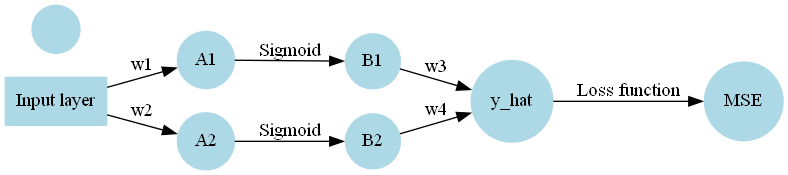

```python
from graphviz import Digraph, Source
import pydotplus
from IPython.display import Image, display

def plot_graph(dot_string):
    # 使用pydotplus将dot字符串转换成图像
    graph = pydotplus.graph_from_dot_data(dot_string)
    # 使用Source方法显示图像
    display(Image(graph.create_png()))

dot_string = '''
digraph {
    rankdir=LR;
    node [shape=circle, style=filled, color=lightblue];
    edge [penwidth=1.0];

    // Input layer
    I [label="Input layer", shape=rect];

    // Hidden layer 1
    H1L1 [label="A1", shape=circle];
    H1L2 [label="A2", shape=circle];

    // Hidden layer 2
    H2R1 [label="B1", shape=circle];
    H2R2 [label="B2", shape=circle];

    // Output layer
    OL [label="y_hat", shape=circle];

    // MSE
    MSE [label="MSE", shape=circle]

    // Connections
    I -> H1L1 [label="w1"];
    I -> H1L2 [label="w2"];
    H1L1 -> H2R1 [label="Sigmoid"];
    H1L2 -> H2R2 [label="Sigmoid"];
    H2R1 -> OL [label="w3"];
    H2R2 -> OL [label="w4"];

    OL -> MSE [label="Loss function"];

}
'''

plot_graph(dot_string)
```

前向传播中，我们可以假设4个 $\omega$ 都为0，然后给定我们的样本，前向传播把每个神经元的值都计算出来。

然后就要用我们的梯度下降法对4个 $\omega$ 进行迭代更新，这就涉及到了反向传播的过程。

首先是 $MSE$ 对 $\hat{y}$ 求偏导：
$$\frac{\partial MSE}{\partial \hat{y}}$$

然后更新我们的$\omega_3$ 和 $\omega_4$ :
$$\omega_3 := \omega_3 - \alpha * \frac{\partial MSE}{\partial \omega_3}$$
$$\omega_4 := \omega_4 - \alpha * \frac{\partial MSE}{\partial \omega_4}$$
这一步是比较经典的梯度下降法嘛，比较好理解，但是神经网络的反向传播就在于后面这个偏导数，他可以用链式求导法则拆分：
$$\omega_3 := \omega_3 - \alpha * \frac{\partial MSE}{\partial \hat{y}} * \frac{\partial \hat{y}}{\partial \omega_3}$$
$$\omega_4 := \omega_4 - \alpha * \frac{\partial MSE}{\partial \hat{y}} * \frac{\partial \hat{y}}{\partial \omega_4}$$

然后更新我们的$\omega_1$ 和 $\omega_2$ :
$$\omega_1 := \omega_1 - \alpha * \frac{\partial MSE}{\partial \hat{y}} * \frac{\partial \hat{y}}{\partial B1} * \frac{\partial B1}{\partial \omega_1}$$
$$\omega_2 := \omega_2 - \alpha * \frac{\partial MSE}{\partial \hat{y}} * \frac{\partial \hat{y}}{\partial B2} * \frac{\partial B2}{\partial \omega_2}$$
这一步怎么来的作为导论阶段不讲太多，有兴趣的同学可以了解一下网络图的求导计算，或者自己按照网络的路径自己推导一下就清晰了。

然后更新完一轮参数之后就再前向传播更新MSE，然后再反向传播更新参数，不断循环迭代。  
最后还有一个问题就是神经网络的应用范围了，神经网络既可以分类也可以回归。  
当我们的最后一层是sigmoid函数或者其他代表概率的函数的时候，神经网络就可以处理分类问题，如果最后一层是线性层，那神经网络就可以处理回归问题。

## 四. 支持向量机（SVM）

支持向量机（Support Vector Machine，简称SVM）是一种二分类模型。  
它的基本思想是在特征空间中寻找一个最优的超平面（或分界线），把不同类别的样本分隔开来，并使得间隔最大化。

我认为全网最详细的SVM博客，理解SVM的三层境界，作为导论，我们只需要理解到第一层，有兴趣的同学可以深入了解。  
https://blog.csdn.net/v_JULY_v/article/details/7624837?ops_request_misc=%257B%2522request

[figure not shown]

**线性可分的支持向量机**

首先介绍线性可分的支持向量机，如上图所示。
当样本点在特征空间中能够被一个超平面完美地分开时，称这个问题是线性可分的。对于二分类问题，超平面可以表示为如下形式的线性方程：
$$\omega^T x + b = 0$$
其中，$\omega$ 是一个向量，称为法向量或者权重向量，$b$ 是一个标量，称为偏置项或者截距项。
我们可以把超平面想象成一个平面或者一条直线，而$\omega$ 就是这个平面或直线的法向量，它的方向垂直于超平面。
偏置 $b$ 决定了超平面与原点的距离，如果 $b>0$，则超平面向上移动，如果 $b<0$，则超平面向下移动。
对应的决策函数为：
$$f(x) = sign(\omega \cdot x + b)$$

其中 $sign(x)$ 为符号函数：
$$\operatorname{sign}(x)=\left\{\begin{array}{ll} -1 & x<0 \\ 0 & x=0 \\ 1 & x>0 \end{array}\right.$$

直线方程和法向量之间有着密切的关系，具体来说，对于一条直线的方程 $ax+by+c=0$，其法向量 $(a,b)$ 是垂直于该直线的向量。  
我们可以将其表示为 $(a,b)\perp(x,y)$，即向量 $(a,b)$ 垂直于点 $(x,y)$ 所在的直线。  
在支持向量机中，我们通过寻找具有最大间隔的超平面来进行分类，这个超平面可以表示为 $w^Tx+b=0$ 的形式，其中 $w$ 是法向量，$b$ 是偏移量。  
这个超平面可以将样本空间分成两个区域，其中一侧为正类，另一侧为负类。  
因此，我们可以利用法向量 $w$ 来表示这个超平面的方向，而 $b$ 则可以决定超平面在样本空间中的位置。  
因此，直线方程和法向量之间的关系在支持向量机中非常重要，  
通过选择合适的法向量和偏移量，我们可以找到具有最大间隔的超平面，从而实现更好的分类效果。

**函数间隔和几何间隔**

在支持向量机中，函数间隔和几何间隔是两个重要的概念。
函数间隔是指一个样本距离超平面的距离，如果该样本被正确分类，函数间隔为正；如果该样本被错误分类，函数间隔为负。
假设超平面的法向量为 $\omega$，偏置为 $b$，样本点为 $x_i$，类别为 $y_i\in{-1,1}$，
则第 $i$ 个样本的函数间隔为：
$$\gamma_i = y_i(\omega \cdot x_i + b)$$
函数间隔越大，则样本被正确分类的可能性越大。
但是，只有函数间隔大并不能保证模型的泛化能力强，因为可以通过调整 $\omega$ 和 $b$ 来增大函数间隔，但是这样往往会导致过拟合。
几何间隔是指一个样本点到超平面的距离，也称为样本点到超平面的“最短距离”,几何间隔相比于函数间隔，更能反映出超平面的“好坏”。
因为几何间隔是通过计算样本点到超平面的实际距离得到的，而函数间隔仅仅是通过超平面的法向量和偏置来计算的。
设超平面的法向量为 $\omega$，偏置为 $b$，样本点为 $x_i$，则第 $i$ 个样本点到超平面的距离为：
$$\gamma_i = \frac{y_i(\omega \cdot x_i + b)}{||\omega||}$$
几何间隔越大，则超平面的性能越好，模型的泛化能力越强。
为了方便理解几何间隔与函数间隔的数学关系，我们用 $\beta$ 来表示函数间隔，$\gamma$ 来表示几何间隔，那么就有：
$$\gamma = \frac{\beta}{||\omega||}$$

**最小间隔最大化**

支持向量机目标函数的思想总结为一句话就是：最大化最小几何间隔。
假设我们的数据集中有 $n$ 个样本点，然后假设我们的超平面已知，那么 $n$ 个样本点到我们的超平面就有 $n$ 个几何间隔距离，即 $n$ 个 $\gamma_i$。
数据集中的样本点到超平面的间隔有大有小,因此肯定存在一个最小几何间隔，数学表达式如下：
$$\hat{\gamma} = \min_{i=1,2...n} \gamma_i$$
其中 $\gamma_i$ 指的是几何间隔。
支持向量机的性能取决于最小的几何间隔有多大，如前面的示例图所示，当支持向量机的几何间隔越大，就相当于我们把两类不同的样本分离的越开。
因此支持向量机的目标函数就是要让最大化数据集中的最小几何间隔。
假设数据中的最小几何间隔为 $\hat{\gamma}$, 因此目标函数可以初步写为：
$$\max \hat{\gamma}$$
$$\text{s.t.} \frac{y_i(\omega \cdot x_i + b)}{||\omega||} \geq \hat{\gamma}, \forall i=1,\ldots,n$$
然后考虑到函数间隔与几何间隔的数学关系，我们可以进一步改写这个目标函数的式子：
$$\max \frac{\hat{\gamma}}{||\omega||}$$
$$\text{s.t.} y_i(\omega \cdot x_i + b) \geq \hat{\gamma}, \forall i=1,\ldots,n$$
此时目标函数中的 $\hat{\gamma}$ 就变成函数间隔了，然后为了计算方便我们可以直接让 $\hat{\gamma} = 1$,因此目标函数进一步精简：
$$\max \frac{1}{||\omega||}$$
$$\text{s.t.} y_i(\omega \cdot x_i + b) \geq 1, \forall i=1,\ldots,n$$
然后把最大化的目标函数转换成最小化：
$$\min \frac{1}{2} ||\omega||^2 $$
$$\text{s.t.} y_i(\omega \cdot x_i + b) \geq 1, \forall i=1,\ldots,n$$
然后就是求解 $\omega$ ，也就是我们的超平面方程了，后面就不属于导论的内容了，后面可以继续补充。

**核函数**

支持向量机的解的构成部分中，包含了向量的内积，即 $k * x_i \cdot x_j$,其中 $k$ 是解的表达式中其他一系列复杂的符号总和，暂时不管。  
线性可分的支持向量机通过求解上述目标函数得到一个线性的分类器，但是大多数问题都是非线性的优化问题。  
支持向量机之所以能够解决非线性的问题就是引入了核函数，核函数能够将低维空间的样本投射到高维空间。  
支持向量机中常见的核函数包括：

1. 线性核函数（Linear Kernel）：$K(x_i, x_j) = x_i^Tx_j$
2. 多项式核函数（Polynomial Kernel）：$K(x_i, x_j) = (x_i^Tx_j + c)^d$
3. 高斯核函数（Gaussian Kernel）：$K(x_i, x_j) = \exp(-\frac{|x_i-x_j|^2}{2\sigma^2})$
4. Sigmoid核函数（Sigmoid Kernel）：$K(x_i, x_j) = \tanh(\alpha x_i^Tx_j + c)$

其中高斯核比较常用。  
通过核函数，可以把解里面的向量内积的部分 $k * x_i \cdot x_j$ 用核函数的结果去替换，从而实现样本的投射以及非线性分类。

**为什么要将样本投射到高维空间**

核函数是一种可以将数据映射到高维空间的函数，它将低维输入空间中的点转换为高维特征空间中的点。  
在高维空间中，数据可能更容易被线性分类器分割。

[figure not shown]

比如说我们可以采用一定的规则把数据映射到高维空间上去，例如两个样本[1,1], [0,0]。  
我们可以使用样本两个坐标的乘积来表示第三个特征,即[1,1,1], [0,0,0]。  
这样我们二维空间的样本就被投射到了三维空间，但是这种方式会带来巨大的计算量，浪费计算资源，所以引入了核函数。  
使用核函数的优点是，可以通过不显式地计算高维空间中的特征向量来避免高维空间中的计算困难，而是通过在原始空间中计算点之间的核函数来实现。

**支持向量机非线性分类的实际案例**

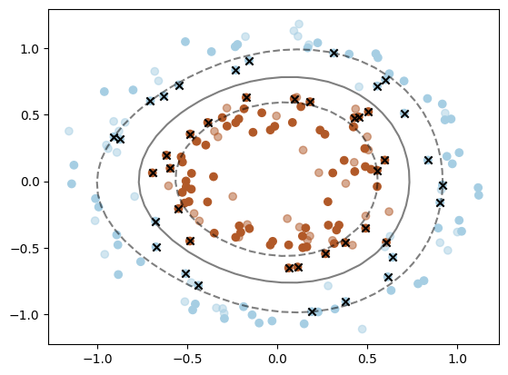

```python
from sklearn.datasets import make_circles
from sklearn.model_selection import train_test_split
from sklearn.svm import SVC
import matplotlib.pyplot as plt
import numpy as np

# 生成一个包含两个特征和两个类别的非线性数据集
X, y = make_circles(n_samples=200, noise=0.1, factor=0.5, random_state=42)

# 将数据集划分为训练集和测试集
X_train, X_test, y_train, y_test = train_test_split(X, y, test_size=0.3, random_state=42)

# 训练一个支持向量机模型
clf = SVC(kernel='rbf', C=1, gamma=1)
clf.fit(X_train, y_train)

# 绘制训练集和测试集的散点图
plt.scatter(X_train[:, 0], X_train[:, 1], c=y_train, cmap=plt.cm.Paired)
plt.scatter(X_test[:, 0], X_test[:, 1], c=y_test, cmap=plt.cm.Paired, alpha=0.5)

# 绘制支持向量
sv = clf.support_vectors_
plt.scatter(sv[:, 0], sv[:, 1], c='k', marker='x')

# 绘制决策平面
ax = plt.gca()
xlim = ax.get_xlim()
ylim = ax.get_ylim()

# 创建网格来评估模型
xx = np.linspace(xlim[0], xlim[1], 30)
yy = np.linspace(ylim[0], ylim[1], 30)
YY, XX = np.meshgrid(yy, xx)
xy = np.vstack([XX.ravel(), YY.ravel()]).T
Z = clf.decision_function(xy).reshape(XX.shape)

# 绘制决策平面和边界
ax.contour(XX, YY, Z, colors='k', levels=[-1, 0, 1], alpha=0.5,
           linestyles=['--', '-', '--'])

plt.show()
```

# **数据挖掘第六章-集成技术**

[figure not shown]

三个臭皮匠，赛过诸葛亮。集成技术就是将一大堆臭皮匠结合起来，让整体模型的各项性能均优于单个模型。  
使用集成技术的主要目的是提高模型的准确性和稳定性，同时减少模型的方差和偏差。  
一般来说，单个机器学习模型可能无法涵盖所有的数据模式和特征，也可能存在一定的误差。  
通过将多个模型的预测结果结合起来，可以更好地捕捉数据的潜在规律，并减少预测误差。

下面介绍几种常用的集成技术：

1. Bagging（袋装法）

Bagging 是一种基于自助采样（bootstrapping）的集成技术,这种技术通常用于降低模型的方差。  
通过使用随机抽取数据集的不同子集来训练不同的模型，然后通过平均或投票的方式来组合它们的结果。  
著名的 Bagging 模型包括随机森林（Random Forest）。  
2. Boosting（提升法）  
Boosting 是一种基于迭代的集成技术，它通过反复训练多个弱分类器来创建一个强分类器。  
这种技术通常用于降低偏差，通过逐步提高分类器的准确性来提高整体性能。  
著名的 Boosting 模型包括 AdaBoost 和 Gradient Boosting。

## 一. 袋装法（bagging）

袋装法（Bagging）是一种常用的集成学习方法，它通过对训练数据进行有放回的随机采样来生成多个不同的训练集，  
并使用这些训练集分别训练出多个不同的基本分类器，再将这些分类器的结果进行组合从而得到最终的预测结果。  
袋装法主要用于降低模型的方差，提高模型的泛化能力，通常应用于决策树等易受样本扰动的分类器上。  
具体地，袋装法的步骤如下：

1. 随机抽样

从原始的训练集中有放回地抽取若干个样本（通常是两个样本数量相同的子集）。  
2. 建立基本分类器  
对于每个样本子集，使用一个基本分类器进行训练，并输出相应的预测结果。  
3. 组合分类器  
将多个基本分类器的预测结果进行组合，通常使用投票法或者平均法进行组合，得到最终的预测结果。

**袋装法实际案例**

假设我们有一个包含5个样本的数据集，每个样本有2个特征，目标变量为二分类问题（0或1）。  
我们可以使用袋装法来训练一个随机森林分类器，以下是一个简单的实例：

|id|特征1| 特征2| 目标变量| |---|---| ---| ---| |1|1.2| 3.5| 0| |2|2.1| 4.5| 0| |3|3.3| 2.1| 1| |4|4.5| 5.5| 1| |5|5.1| 4.9| 1|

我们将数据集分成两个子集，每个子集包含3个随机选择的样本（有放回地抽样）。  
抽取样本的方法比较多样，比如我们抽取了id:[1, 2, 3]这三个样本。  
第一种抽取方法完整的抽取样本的所有信息：

|id|特征1| 特征2| 目标变量| |---|---| ---| ---| |1|1.2| 3.5| 0| |2|2.1| 4.5| 0| |3|3.3| 2.1| 1|

第二种抽取方法是我们可以抽取样本中的部分信息，即从样本的特征列中随机选取一些列出来：

|id|特征1| 目标变量| |---|---| ---| |1|1.2| 0| |2|2.1| 0| |3|3.3| 1|

假设我们采取的是第二种抽取方式，然后从数据集中抽取出两个子集，分别用两个子集去训练一个决策树模型，比如得到两个模型：

|id|特征1| 目标变量| |---|---| ---| |1|1.2| 0| |2|2.1| 0| |3|3.3| 1|

|id| 特征2| 目标变量| |---| ---| ---| |1| 3.5| 0| |2| 4.5| 0| |3| 2.1| 1|

Decision Tree 1:

```
      feature_1 >= 3.3
      /           \
  class 0           class 1
```

Decision Tree 2:

```
      feature_2 >= 4.5
      /           \
  class 1           class 0
```

**袋装法中模型结果的融合方法**

1. 简单投票（Majority Voting）

对于每个新的数据点，每个子模型都会产生一个预测结果，最终的预测结果是所有预测结果中出现最多的类别。这种方法通常用于分类问题。  
2. 加权投票（Weighted Voting）  
在简单投票的基础上，可以为每个子模型分配一个权重，最终的预测结果是所有预测结果加权后出现最多的类别。  
权重可以根据子模型的准确率、复杂度等进行分配。  
3. 平均投票（Averaging）  
对于回归问题，可以将所有子模型的预测结果取平均值作为最终的预测结果。  
4. 加权平均投票（Weighted Averaging）  
在平均投票的基础上，可以为每个子模型分配一个权重，最终的预测结果是所有预测结果加权平均后得到的值。  
权重可以根据子模型的准确率、复杂度等进行分配。

## 二. 提升法（boosting）

Boosting是一种集成学习方法，它通过逐步提升弱学习器的性能来构建一个强学习器。  
与Bagging不同的是，Boosting是一种串行方法，bagging是利用多个弱学习器去拟合数据集，然后做投票，模型之间彼此不关联，各做各的。  
boosting的原理和bagging的原理有所不同，boosting是基于上一个模型学习的结果，然后继续对数据集去学习。  
这样，Boosting可以有效地提高模型的泛化能力和精度。常见的Boosting方法包括：

1. AdaBoost（Adaptive Boosting）

AdaBoost是一种基于加权投票的Boosting方法，它通过逐步提升弱学习器的准确率来构建一个强学习器。  
在每个迭代中，AdaBoost会为错误分类的数据点分配更高的权重，以便在下一次训练中得到更多的关注。  
此外，AdaBoost还会为每个弱学习器分配一个权重，用于决定它们在最终模型中的重要性。  
2. Gradient Boosting  
Gradient Boosting是一种基于梯度下降的Boosting方法，它用损失函数的梯度来表示残差，通过持续迭代来构建一个强学习器。  
在每个迭代中，Gradient Boosting会计算当前模型对训练数据的预测结果与真实结果之间的残差，并使用残差来训练一个新的弱学习器。  
此外，Gradient Boosting还会为每个弱学习器分配一个权重，用于决定它们在最终模型中的重要性。

由于是导论部分，所以对AdaBoost和GBDT不做过多讲解，先理解下面的算法案例，然后回头再看这两个算法，能简单理解即可。  
下面我用一个简单的案例讲解一下boosting的基本原理。

**boosting算法案例**

假设我们有一个10行2列的数据集，问题是一个回归问题，我们采用决策树算法作为基模型，用boosting去对模型做提升。

| x1 | label |
| --- | --- |
| 1 | 5.56 |
| 2 | 5.70 |
| 3 | 5.91 |
| 4 | 6.40 |
| 5 | 6.80 |
| 6 | 7.05 |
| 7 | 8.90 |
| 8 | 8.70 |
| 9 | 9.00 |
| 10 | 9.05 |

首先我们对 $x_1$ 和 $label$ 拟合了一个决策树模型，分类规则如下图所示，预测结果在 predict_1列 中。  
单个决策树模型就完了，提升树模型对第一个模型的残差部分继续拟合，残差: $residual = label - predict_1$

```python
import numpy as np
import pandas as pd
from sklearn.tree import DecisionTreeRegressor,export_graphviz
from sklearn.metrics import mean_squared_error as MSE
from graphviz import Source

df = pd.DataFrame()
df['x1'] = range(1,11)
df['label'] = [5.56,5.70,5.91,6.40,6.80,7.05,8.90,8.70,9.00,9.05]
model = DecisionTreeRegressor(max_depth=1).fit(df.loc[:, ['x1']], df.loc[:, 'label'])
df['predict_1'] = model.predict(df.loc[:, ['x1']])
dot_file = export_graphviz(model, out_file=None)
Source(dot_file)
```

[figure not shown]

```python
df['residual'] = df['label'] - df['predict_1']
df
```

|  | x1 | label | predict_1 | residual |
| --- | --- | --- | --- | --- |
| 0 | 1 | 5.56 | 6.236667 | -0.676667 |
| 1 | 2 | 5.70 | 6.236667 | -0.536667 |
| 2 | 3 | 5.91 | 6.236667 | -0.326667 |
| 3 | 4 | 6.40 | 6.236667 | 0.163333 |
| 4 | 5 | 6.80 | 6.236667 | 0.563333 |
| 5 | 6 | 7.05 | 6.236667 | 0.813333 |
| 6 | 7 | 8.90 | 8.912500 | -0.012500 |
| 7 | 8 | 8.70 | 8.912500 | -0.212500 |
| 8 | 9 | 9.00 | 8.912500 | 0.087500 |
| 9 | 10 | 9.05 | 8.912500 | 0.137500 |

然后我们对 $x_1$ 和 $residual$ 继续拟合第二个决策树模型，得到predict_2列，决策树如第二张决策树图所示。

```python
model2 = DecisionTreeRegressor(max_depth=1).fit(df.loc[:, ['x1']], df.loc[:, 'residual'])
df['predict_2'] = model2.predict(df.loc[:, ['x1']])
dot_file2 = export_graphviz(model2, out_file=None)
Source(dot_file2)
```

[figure not shown]

```python
df
```

|  | x1 | label | predict_1 | residual | predict_2 |
| --- | --- | --- | --- | --- | --- |
| 0 | 1 | 5.56 | 6.236667 | -0.676667 | -0.513333 |
| 1 | 2 | 5.70 | 6.236667 | -0.536667 | -0.513333 |
| 2 | 3 | 5.91 | 6.236667 | -0.326667 | -0.513333 |
| 3 | 4 | 6.40 | 6.236667 | 0.163333 | 0.220000 |
| 4 | 5 | 6.80 | 6.236667 | 0.563333 | 0.220000 |
| 5 | 6 | 7.05 | 6.236667 | 0.813333 | 0.220000 |
| 6 | 7 | 8.90 | 8.912500 | -0.012500 | 0.220000 |
| 7 | 8 | 8.70 | 8.912500 | -0.212500 | 0.220000 |
| 8 | 9 | 9.00 | 8.912500 | 0.087500 | 0.220000 |
| 9 | 10 | 9.05 | 8.912500 | 0.137500 | 0.220000 |

然后我们把 predict_1 和 predict_2 加起来作为最后预测的结果，结果如 final列 所示。  
你会发现经过boosting之后，final对数据集的拟合程度明显比predict_1的拟合程度好了很多。

```python
df['final'] = df['predict_1'] + df['predict_2']
df
```

|  | x1 | label | predict_1 | residual | predict_2 | final |
| --- | --- | --- | --- | --- | --- | --- |
| 0 | 1 | 5.56 | 6.236667 | -0.676667 | -0.513333 | 5.723333 |
| 1 | 2 | 5.70 | 6.236667 | -0.536667 | -0.513333 | 5.723333 |
| 2 | 3 | 5.91 | 6.236667 | -0.326667 | -0.513333 | 5.723333 |
| 3 | 4 | 6.40 | 6.236667 | 0.163333 | 0.220000 | 6.456667 |
| 4 | 5 | 6.80 | 6.236667 | 0.563333 | 0.220000 | 6.456667 |
| 5 | 6 | 7.05 | 6.236667 | 0.813333 | 0.220000 | 6.456667 |
| 6 | 7 | 8.90 | 8.912500 | -0.012500 | 0.220000 | 9.132500 |
| 7 | 8 | 8.70 | 8.912500 | -0.212500 | 0.220000 | 9.132500 |
| 8 | 9 | 9.00 | 8.912500 | 0.087500 | 0.220000 | 9.132500 |
| 9 | 10 | 9.05 | 8.912500 | 0.137500 | 0.220000 | 9.132500 |

# **数据挖掘第七章-频繁规则挖掘**

[figure not shown]

频繁模式挖掘（Frequent Pattern Mining）是数据挖掘领域中的一个重要任务。  
它的目标是从一个数据集中找出经常出现在一起的物品或者属性的组合，这些组合称为频繁项集（Frequent Itemsets）。  
频繁项集在许多应用场景中都非常有用，例如购物篮分析、推荐系统、生物信息学等领域。  
其中最常见的应用是购物篮分析，通过发现哪些商品经常被一起购买，商家可以进行更有效的产品定位、营销策略制定以及库存管理。

频繁模式挖掘的基本算法包括Apriori算法、FP-growth算法等。  
Apriori算法是一种基于候选生成的算法，其核心思想是利用频繁项集的性质，从候选项集中生成更大的候选项集，并逐步筛选出频繁项集。  
FP-growth算法则是一种基于数据结构的算法，它通过构建一种称为FP树的数据结构来避免生成候选项集，从而提高了挖掘频繁项集的效率

在频繁模式挖掘中，还有一些常用的度量指标，例如支持度、置信度和提升度等。  
总之，频繁模式挖掘是一种重要的数据挖掘技术，它可以用来发现数据集中的潜在规律和关联关系，并在很多实际应用中发挥着重要的作用。

## 一. 基本概念

当进行频繁模式挖掘时，会涉及到一些重要的概念。以下是这些概念的详细解释：

1. 项集（Itemset）

项集是指一个或多个项（Item）的集合。在购物篮分析中，每个项代表一种商品，而项集则表示购物篮中的商品组合。  
2. 频繁项集（Frequent Itemset）  
频繁项集是指在数据集中经常出现的项集。通常会根据支持度来定义频繁项集，即出现频率超过某个预设阈值的项集。  
3. 支持度（Support）  
支持度是指在数据集中某个项集出现的频率，也就是该项集出现的次数除以数据集中的总项数。通常用百分比或小数表示。  
4. 候选项集（Candidate Itemset）  
候选项集是指在频繁模式挖掘算法中生成的待验证项集。对于一个给定的数据集，候选项集由数据集中的项组成。  
5. 频繁项集规模（Itemset Size）  
频繁项集规模是指频繁项集中包含的项的个数。例如，{A, B}和{A, B, C}都是频繁项集，其中前者规模为2，后者规模为3。  
6. 关联规则（Association Rule）  
关联规则是指形如A -> B的逻辑表达式，其中A和B是两个项集。  
关联规则用来描述两个项集之间的关联关系，通常使用置信度和支持度来描述关联规则的强度。  
7. 置信度（Confidence）  
置信度是指当一个项集A出现时，另一个项集B也同时出现的概率，即P(B|A)。置信度通常用百分比或小数表示。  
8. 提升度（Lift）  
提升度是指当一个项集A出现时，另一个项集B出现的概率相对于它们分别独立出现的概率的提升程度，即P(B|A) / P(B)。  
提升度大于1表示A和B之间存在正相关关系，小于1表示负相关关系，等于1表示A和B之间不存在关联关系。

**计算案例**  
假设我们有以下数据集，其中每个数字表示一个商品的编号：

| 篮子 |
| --- |
| {1 2 3} |
| {1 2 4} |
| {1 3 4} |
| {2 3 4} |
| {1 2} |
| {1 3} |

## 二. Apriori算法

Apriori算法是一种常用的关联规则挖掘算法，用于从大规模数据集中挖掘频繁项集和关联规则。该算法基于两个重要的概念：支持度和置信度。  
支持度是指一个项集在数据集中出现的频率，置信度是指在包含某个项集的事务中，该项集的后继也会出现的概率。  
Apriori算法的基本思路是：首先找到频繁项集，然后利用频繁项集产生关联规则。  
Apriori算法主要分为两个步骤：

1. 候选集生成

通过对数据集进行扫描，生成所有可能的项集，称之为候选项集。  
候选项集是指包含k个项的集合，其中k表示当前的扫描轮次。  
例如，在第一轮扫描中，候选项集就是数据集中的所有项。  
而在第二轮扫描中，候选项集是通过组合第一轮扫描中的频繁项集生成的，以此类推。  
2. 频繁项集生成  
在候选项集生成之后，需要对每个候选项集进行支持度计数，计算其出现的频率。  
如果候选项集的频率超过了预先设定的阈值，那么就将其加入到频繁项集中。频繁项集是指出现频率超过阈值的项集。

**算法案例**

假设我们有如下购物篮子数据：

| 篮子 |
| --- |
| {1 2 3} |
| {2,3,4} |
| {1,2,3,4} |
| {1,2} |
| {1,3} |
| {2,3} |
| {1,4} |
| {3,4} |

现在我们希望使用Apriori算法来挖掘其中的频繁项集和关联规则。我们设定一个最小支持度--阈值为4，置信度阈值为0.5。

**频繁项集挖掘**

第一轮扫描：统计所有单个项的出现频率  
{1}: 5次  
{2}: 5次  
{3}: 6次  
{4}: 4次  
然后我们去掉支持度不足4次的候选项集，没有任何改变。

第二轮扫描：统计所有两个项的出现频率，这一步可以直接在第一轮扫描的结果中相互交叉即可，交叉出结果然后再去统计次数。  
{1，2}: 3次  
{1，3}: 3次  
{1，4}: 2次  
{2，3}: 4次  
{2，4}: 2次  
{3，4}: 3次  
然后我们去掉支持度不足4次的候选项集。  
{2，3}: 4次  
只剩下最后一个了，所以频繁项集的挖掘就只能停止了，在实际中可以自己选择计算到几项集。

**产生关联规则**

我们可以基于频繁一项集来产生关联规则：  
{1} => {2}: 3/5  
{1} => {3}: 3/5  
{1} => {4}: 2/5  
{2} => {3}: 4/5  
{2} => {4}: 2/5  
{3} => {4}: 3/6  
根据置信度的阈值，置信度大于0.5的规则才会被认为是有意思的规则。因此筛选如下规则：  
{1} => {2}: 3/5  
{1} => {3}: 3/5  
{2} => {3}: 4/5

## 三. FP-growth算法

P-growth算法是一种基于FP树的频繁模式挖掘算法，  
其主要思想是将数据集压缩成一棵FP树，然后利用该树结构来挖掘频繁项集。  
FP-growth算法主要包含以下两个步骤：

1. 构建FP树

对于每个样本，FP-growth算法会遍历其中的项并按照支持度进行排序，然后根据排序后的项依次插入FP树中。  
FP树是一种紧凑型数据结构，它通过共享相同前缀的路径来节省空间。在FP树中，  
每个节点包含一个项、计数值和指向其父节点的指针以及指向它的第一个孩子节点的指针。  
2. 挖掘频繁项集  
对于每个项，FP-growth算法会通过迭代方法来挖掘其对应的频繁项集。具体地，  
该算法会首先找到所有包含该项的前缀路径，然后基于这些前缀路径构建条件模式基，并以此递归构建条件FP树。  
最后，通过对条件FP树递归地应用上述步骤，可以得到该项对应的所有频繁项集。

相比于Apriori算法，FP-growth算法具有更高的效率，因为它使用了一种更紧凑的数据结构来表示数据集，  
同时在挖掘频繁项集时采用了递归的方式，避免了重复扫描数据集的问题。

**算法案例**

Referrence:https://blog.csdn.net/qq_45060674/article/details/117305780

| 数据集 |
| --- |
| {a b c e f o} |
| {a c g} |
| {e i} |
| {a c d e g} |
| {a c e g l} |
| {e j} |
| {a b c e f p} |
| {a c d} |
| {a c e g m} |
| {a c e g n} |

第一步：先扫描数据集中的一项集，支持度阈值我们设置为20%，然后把低于支持度的一项集删除掉。

| 一项集 | 支持度 |
| --- | --- |
| {a} | 8 |
| {c} | 8 |
| {e} | 8 |
| {g} | 5 |
| {b} | 2 |
| {d} | 2 |
| {f} | 2 |

第二步：对原始数据按照支持度的大小顺序重新排列,如果样本中出现非频繁一项集，就把非频繁项删除掉。

| 数据集 |
| --- |
| {a c e b f} |
| {a c g} |
| {e} |
| {a c e g d} |
| {a c e g} |
| {e} |
| {a c e b f} |
| {a c d} |
| {a c e g} |
| {a c e g} |

第三步：以null节点为开始，然后依次插入数据集中的数据。首先插入第一条数据 {a c e b f}：  
我们用缩进来代表树节点的关系。

null a:1 c:1 e:1 b:1 f:1

插入第二条数据，如果新数据的路径没出现在原本的路径上，就分叉。

插入{a c g} null a:2 c:2 e:1 b:1 f:1 g:1

如果数据的开头项就没有出现在原始路径中，就从null节点建立新的分支。

插入{e} null a:2 c:2 e:1 b:1 f:1 g:1 e:1

插入{a c e g d} null a:3 c:3 e:2 b:1 f:1 g:1 d:1 g:1 e:1

插入{a c e g} null a:4 c:4 e:3 b:1 f:1 g:2 d:1 g:1 e:1

插入{e} null a:4 c:4 e:3 b:1 f:1 g:2 d:1 g:1 e:2

插入{a c e b f} null a:5 c:5 e:4 b:2 f:2 g:2 d:1 g:1 e:2

插入{a c d} null a:6 c:6 e:4 b:2 f:2 g:2 d:1 g:1 d:1 e:2

插入{a c e g}和{a c e g} null a:8 c:8 e:6 b:2 f:2 g:4 d:1 g:1 d:1 e:2

| 一项集 | 支持度 |
| --- | --- |
| {a} | 8 |
| {c} | 8 |
| {e} | 8 |
| {g} | 5 |
| {b} | 2 |
| {d} | 2 |
| {f} | 2 |

我们需要从频繁项集表的底部开始看，第一个节点是F。那我们就去FP树里面找F点的路径。

null a:8 c:8 e:6 b:2 f:2

首先看F节点，很容易得到F的频繁2项集为{A:2,F:2}, {C:2,F:2}, {E:2,F:2}, {B:2,F:2}。  
递归合并二项集，得到频繁三项集为{A:2,C:2,F:2}，{A:2,E:2,F:2},…还有一些频繁三项集。  
当然一直递归下去，最大的频繁项集为频繁5项集，为{A:2,C:2,E:2,B:2,F:2}

null a:8 c:8 e:6 b:2 f:2 g:4 d:1 g:1 d:1

D节点会比较特殊一点，有两条路径，单个节点来看，D节点的支持度都是不够的。  
但是两条路径在C节点的汇合处满足了最低支持度的要求，所以用D节点去生成频繁项集只能从C节点开始。

其余的生成方式都一致，一直到null节点的下一层为止。

# **数据挖掘第八章-机器学习竞赛技巧**

[figure not shown]

# 数据来源

```
Citation Request:
  This dataset is public available for research. The details are described in [Moro et al., 2011].
  Please include this citation if you plan to use this database:

  [Moro et al., 2011] S. Moro, R. Laureano and P. Cortez. Using Data Mining for Bank Direct Marketing: An Application of the CRISP-DM Methodology.
  In P. Novais et al. (Eds.), Proceedings of the European Simulation and Modelling Conference - ESM'2011, pp. 117-121, Guimarães, Portugal, October, 2011. EUROSIS.

  Available at: [pdf] http://hdl.handle.net/1822/14838
                [bib] http://www3.dsi.uminho.pt/pcortez/bib/2011-esm-1.txt

1. Title: Bank Marketing

2. Sources
   Created by: Paulo Cortez (Univ. Minho) and Sérgio Moro (ISCTE-IUL) @ 2012
```

```python
import pandas as pd
import numpy as np
import missingno as msno
import matplotlib.pyplot as plt
import seaborn as sns
import matplotlib
import copy
import time
import datetime
import json
from tqdm import tqdm
from scipy.stats import skew
from sklearn.model_selection import train_test_split, StratifiedKFold, KFold, cross_val_score, GridSearchCV
from sklearn.preprocessing import MinMaxScaler, LabelEncoder, OneHotEncoder
from sklearn.metrics import mean_squared_error as mse
from sklearn.preprocessing import MinMaxScaler, LabelEncoder
from sklearn.ensemble import RandomForestClassifier, RandomForestRegressor, GradientBoostingRegressor, ExtraTreesRegressor,GradientBoostingClassifier, ExtraTreesClassifier
import warnings
warnings.filterwarnings('ignore')
```

```python
path = r'C:\Users\admin\bank-full.csv'
data = pd.read_csv(path, delimiter=';')
```

# 数据集概况

```
我们的数据集是45211*17，意味着我们的数据有45211个样本，以及16个特征，另外一列是我们的标签变量。
然后大概看看每一个变量都是以什么形式记录的。
age--年龄  连续型变量
job--工作  分类型变量
mariral--婚姻  分类型变量
education--教育情况  分类型变量
default--违约情况  分类型变量
balance--年平均余额  连续型变量
housing--是否有房贷  分类型变量
loan--是否有贷款  分类型变量
contact--联系方式类型  分类型变量
day--最后联系日  连续型变量
month--最后联系月  分类型变量
duration--最后通话时长  连续型变量
campaign--联系次数  连续型变量
pdays--距离上次通话过了多少天  连续型变量 -1表示没有联系过
previous--在活动之前与客户联系过的次数  连续型变量
poutcome--先前营销的结果  分类型变量

看了数据集之后就可以产生大致的数据预处理的思路了
```

```python
data
```

|  | age | job | marital | education | default | balance | housing | loan | contact | day | month | duration | campaign | pdays | previous | poutcome | y |
| --- | --- | --- | --- | --- | --- | --- | --- | --- | --- | --- | --- | --- | --- | --- | --- | --- | --- |
| 0 | 58 | management | married | tertiary | no | 2143 | yes | no | unknown | 5 | may | 261 | 1 | -1 | 0 | unknown | no |
| 1 | 44 | technician | single | secondary | no | 29 | yes | no | unknown | 5 | may | 151 | 1 | -1 | 0 | unknown | no |
| 2 | 33 | entrepreneur | married | secondary | no | 2 | yes | yes | unknown | 5 | may | 76 | 1 | -1 | 0 | unknown | no |
| 3 | 47 | blue-collar | married | unknown | no | 1506 | yes | no | unknown | 5 | may | 92 | 1 | -1 | 0 | unknown | no |
| 4 | 33 | unknown | single | unknown | no | 1 | no | no | unknown | 5 | may | 198 | 1 | -1 | 0 | unknown | no |
| ... | ... | ... | ... | ... | ... | ... | ... | ... | ... | ... | ... | ... | ... | ... | ... | ... | ... |
| 45206 | 51 | technician | married | tertiary | no | 825 | no | no | cellular | 17 | nov | 977 | 3 | -1 | 0 | unknown | yes |
| 45207 | 71 | retired | divorced | primary | no | 1729 | no | no | cellular | 17 | nov | 456 | 2 | -1 | 0 | unknown | yes |
| 45208 | 72 | retired | married | secondary | no | 5715 | no | no | cellular | 17 | nov | 1127 | 5 | 184 | 3 | success | yes |
| 45209 | 57 | blue-collar | married | secondary | no | 668 | no | no | telephone | 17 | nov | 508 | 4 | -1 | 0 | unknown | no |
| 45210 | 37 | entrepreneur | married | secondary | no | 2971 | no | no | cellular | 17 | nov | 361 | 2 | 188 | 11 | other | no |

45211 rows × 17 columns